# Code used in ‘Residential wood burning and pulmonary function in the Agricultural Lung Health Study’ manuscript

Julie D. White

Jul 13, 2022

# Packages

```r
library(tidyverse)
library(survey)
library(Gmisc)
library(gtsummary)
theme_gtsummary_compact()
```

```
## Setting theme `Compact`
```

```r
library(flextable)
```

# Data

Loading and manipulating the data to convert some to factors and create wood burning exposure variable.

```r
# Most of the phenotype data
pheno <- haven::read_sas("../data/lhs26801_pahanalyticvars_21sep02.sas7bdat")

# COPD information
copd <- readr::read_csv("../data/LHS26801_COPDPlus_29Mar22.txt",
                        col_types = c('d', 'c', 'c', 'c', 'c', 'c', 'c', 'c'))

pheno <- dplyr::left_join(x = pheno, y = copd, by = "LHID") %>%
  mutate(across(.cols = c(gender, race_B, state, LH_smoke_status, FTSC_season_v2,
                          LHSScreen_12142015, Im_Atopic_Spec_v2, XH38, P1_educ_v3,
                          P3_COPDorEMPHYSEMA, FTSC_FeNOBIN), as.factor),
         # Create Wood burning exposure variable
         WoodExp = factor(case_when(
           # No exposure, as best we can judge
           XH34 != 5 & # Main heating fuel not wood
             XH36e == 0 & # Secondary heating fuel not wood
             XH37 %in% c(NA_real_, 0) & # Wood stove use NA or never
             XH40 %in% c(NA_real_, 0) ~ 0, # Fireplace use NA or never
           # Lots of fireplace or wood stove exposure
           XH39 %in% c(3, 4) ~ 2, # Wood stove use freq or most days/nights
           XH41 %in% c(3, 4) ~ 2, # Fireplace use freq or most days/nights
           # Some fireplace or wood stove exposure
           XH39 %in% c(1, 2) ~ 1, # Wood stove use rarely or occasionally
           XH41 %in% c(1, 2) ~ 1, # Fireplace use rarely or occasionally
           # Some exposure from primary or secondary heating
           XH34 == 5 ~ 1, # Main heating fuel is wood
           XH36e == 1 ~ 1, # Secondary heating fuel is wood
           # Don't fit into any of the above
           TRUE ~ NA_real_)),
         # Manual interaction between wood exposure and asthma status
         WoodExpAsthmaInt = factor(case_when(
           WoodExp == 0 & LHSScreen_12142015 == 0 ~ "Unexp-Noncase",
           WoodExp == 1 & LHSScreen_12142015 == 0 ~ "Some-Noncase",
           WoodExp == 2 & LHSScreen_12142015 == 0 ~ "Freq-Noncase",
           WoodExp == 0 & LHSScreen_12142015 == 1 ~ "Unexp-Case",
           WoodExp == 1 & LHSScreen_12142015 == 1 ~ "Some-Case",
           WoodExp == 2 & LHSScreen_12142015 == 1 ~ "Freq-Case"),
           levels = c("Unexp-Noncase", "Some-Noncase", "Freq-Noncase", "Unexp-Case",
                      "Some-Case", "Freq-Case")),
         # Manual interaction between wood exposure and smoking status
         WoodExpSmokingInt = factor(case_when(
           WoodExp == 0 & LH_smoke_status == 1 ~ "Unexp-Never",
           WoodExp == 1 & LH_smoke_status == 1 ~ "Some-Never",
           WoodExp == 2 & LH_smoke_status == 1 ~ "Freq-Never",
           WoodExp == 0 & LH_smoke_status == 2 ~ "Unexp-Former",
           WoodExp == 1 & LH_smoke_status == 2 ~ "Some-Former",
           WoodExp == 2 & LH_smoke_status == 2 ~ "Freq-Former",
           WoodExp == 0 & LH_smoke_status == 3 ~ "Unexp-Current",
           WoodExp == 1 & LH_smoke_status == 3 ~ "Some-Current",
           WoodExp == 2 & LH_smoke_status == 3 ~ "Freq-Current"),
           levels = c("Unexp-Never", "Some-Never", "Freq-Never", "Unexp-Former",
                      "Some-Former", "Freq-Former", "Unexp-Current", "Some-Current",
                      "Freq-Current")))

table(pheno$WoodExp, useNA = "ifany")
```

```
##
##    0    1    2 <NA>
## 2555  286  394   66
```

Subset the data to remove individuals with missing or invalid PFT scores, one of each household where farmer and spouse received their home visit at the same address, and covariate or exposure data.

```r
# Subset to individuals with PFTs, and with valid QFVC scores
pheno_analysis <- pheno %>%
  drop_na(FEV1_01) %>%
  filter(QFVC_01 %in% c("A", "B", "C"))

# Randomly select one member of each household where farmer and spouse received
# their home visit at the same address
set.seed(543)
paired_household_random <- pheno_analysis %>%
  group_by(partid) %>%  # Household indicator
  filter(n() > 1) %>% # Two people from the same household
  filter(sameaddr == "yes") %>% # Living at the same address
  sample_n(1) %>% #Randomly choose one from each household
  select(partid, LHID)

# Subset our analysis data frame to remove these people
pheno_analysis <- pheno_analysis %>%
  filter(!LHID %in% paired_household_random$LHID) %>%
  # Drop missing information in our analytic variables
  drop_na(WoodExp, pft_age, pft_age_sq, gender, race_B, LH_Height, Height_2,
          LH_Weight, state, LH_smoke_status, LH_packyears)

table(pheno_analysis$WoodExp, useNA = "ifany")
```

```
##
##    0    1    2
## 2217  250  348
```

Create survey design object based on asthma status proportions in our sample vs. the parent study.

```r
# Calculate weights based on selection probability
p_asthma_overall = 3024/(41106+3024) # Proportion of cases in the AHS
p_asthma_nested = # Proportion of cases in analytic sample
  nrow(pheno_analysis[pheno_analysis$LHSScreen_12142015 == 1,])/nrow(pheno_analysis)
p_nonasthma_overall = 41106/(41106+3024) # Proportion of noncases in the AHS
p_nonasthma_nested = # Proportion of noncases in analytic sample
  nrow(pheno_analysis[pheno_analysis$LHSScreen_12142015 == 0,])/nrow(pheno_analysis)

# Assign the inverse probability of those weights based on case status
pheno_analysis <-
  mutate(pheno_analysis,
         lhsscreen_12142015_weight = case_when(
           LHSScreen_12142015 == 0 ~ 1/(p_nonasthma_nested/p_nonasthma_overall),
           LHSScreen_12142015 == 1 ~ 1/(p_asthma_nested/p_asthma_overall),
           TRUE ~ NA_real_))

table(pheno_analysis$lhsscreen_12142015_weight, useNA = "ifany")
```

```
##
## 0.178113895422301   1.5139160804028
##              1083              1732
```

```r
# Create survey design object
pheno_analysis_surv <- svydesign(id = ~LHID, strata = ~LHSScreen_12142015,
                                 weights = ~lhsscreen_12142015_weight,
                                 data = pheno_analysis)
```

Create a separate dataframe for the FeNO analysis

```r
pheno_analysis_feno <- pheno_analysis %>%
  # 5 ppb is the detection limit for the NIOX MINO, so setting values below that
  # as LOD / sqrt2. FeNO is then log transformed because it is right skewed
  mutate(FTSC_eNO_Average_Win = case_when(FTSC_eNO_Average < 5 ~ 5/sqrt(2),
                                          TRUE ~ FTSC_eNO_Average),
         FTSC_eNO_Average_Win_log = log(FTSC_eNO_Average_Win)) %>%
  # Drop missing information in our additional analytic variables
  drop_na(FTSC_eNO_Average_Win_log, Im_Atopic_Spec_v2)

table(pheno_analysis_feno$WoodExp, useNA = "ifany")
```

```
##
##    0    1    2
## 2040  235  323
```

```r
# Calculate selection probability weights on the feno analytic sample
p_asthma_feno =
  nrow(pheno_analysis_feno[pheno_analysis_feno$LHSScreen_12142015 == 1,])/nrow(pheno_analysis_feno)
p_nonasthma_feno =
  nrow(pheno_analysis_feno[pheno_analysis_feno$LHSScreen_12142015 == 0,])/nrow(pheno_analysis_feno)

# Assign inverse probability weights
pheno_analysis_feno <- pheno_analysis_feno %>%
  mutate(lhsscreen_12142015_weight =
           case_when(LHSScreen_12142015 == 0 ~ 1/(p_nonasthma_feno/p_nonasthma_overall),
                     LHSScreen_12142015 == 1 ~ 1/(p_asthma_feno/p_asthma_overall),
                     TRUE ~ NA_real_))

table(pheno_analysis_feno$lhsscreen_12142015_weight)
```

```
##
## 0.177318191543818   1.5181759947867
##              1004              1594
```

```r
# Create survey design object
pheno_analysis_feno_surv <- svydesign(id = ~LHID, strata = ~LHSScreen_12142015,
                                      weights = ~lhsscreen_12142015_weight,
                                      data = pheno_analysis_feno)
```

Report the percentage of people with FeNO values below the limit of detection

```r
signif(length(which(pheno_analysis_feno$FTSC_eNO_Average < 5)) /
         length(which(!is.na(pheno_analysis_feno$FTSC_eNO_Average))) * 100,
       digits = 2)
```

```
## [1] 6.4
```

Report the average lag time between the wood burning survey and home visit

```r
pheno_analysis %>% select(FTSC_DATE, CATICompleteDate) %>%
  mutate(lag = as.numeric(CATICompleteDate - FTSC_DATE)) %>%
  summarize(median = median(lag), first_quartile = quantile(lag, 0.25),
            third_quartile = quantile(lag, 0.75))
```

```
## # A tibble: 1 × 3
##   median first_quartile third_quartile
##    <dbl>          <dbl>          <dbl>
## 1      9              7             16
```

# SI Figure 1: Sample size flow chart

Calculate numbers for each exclusion criteria

```r
# Number of total ALHS individuals
a_num <- nrow(pheno)
# Number of individuals with complete PFTs
b1_num <- nrow(pheno %>% drop_na(FEV1_01, FVC_01, RATIO1_01_r))

# Number of individuals with incomplete PFTs
b2_num <- nrow(pheno %>%
                 dplyr::select(FEV1_01, FVC_01, RATIO1_01_r) %>%
                 filter_all(any_vars(is.na(.))))
# Number of individuals with FVC score of at least C
c1_num <- nrow(pheno %>%
                 drop_na(FEV1_01, FVC_01, RATIO1_01_r) %>%
                 filter(QFVC_01 %in% c("A", "B", "C")))
# Number of individuals with FVC score of D or F
c2_num <- nrow(pheno %>%
                 drop_na(FEV1_01, FVC_01, RATIO1_01_r) %>%
                 filter(QFVC_01 %in% c("D", "F")))
# Number of individuals after removing one of each household
d1_num <- nrow(pheno %>%
                 drop_na(FEV1_01, FVC_01, RATIO1_01_r) %>%
                 filter(QFVC_01 %in% c("A", "B", "C")) %>%
                 filter(!LHID %in% paired_household_random$LHID))
# Number of individuals removed from paired households
d2_num <- c1_num - d1_num
# Number of individuals after removing missing covariates & WoodExp
e1_num <- nrow(pheno %>%
                drop_na(FEV1_01, FVC_01, RATIO1_01_r) %>%
                filter(QFVC_01 %in% c("A", "B", "C")) %>%
                filter(!LHID %in% paired_household_random$LHID) %>%
                drop_na(WoodExp, pft_age, pft_age_sq, gender, race_B, LH_Height,
                        Height_2, LH_Weight, state, LH_smoke_status,
                        LH_packyears))
# Number of individuals unable to categorize
e2_num <- nrow(pheno %>%
                drop_na(FEV1_01, FVC_01, RATIO1_01_r) %>%
                filter(QFVC_01 %in% c("A", "B", "C")) %>%
                filter(!LHID %in% paired_household_random$LHID) %>%
                drop_na(pft_age, pft_age_sq, gender, race_B, LH_Height,
                        Height_2, LH_Weight, state, LH_smoke_status,
                        LH_packyears) %>%
                 filter(is.na(WoodExp)))
# Number of individuals missing covariates
e3_num <- d1_num - e1_num - e2_num

# Unexposed
f_num = nrow(pheno_analysis %>% filter(WoodExp == 0))
# Mildly exposed
g_num = nrow(pheno_analysis %>% filter(WoodExp == 1))
# Moderate to Frequent exposure
h_num = nrow(pheno_analysis %>% filter(WoodExp == 2))
```

Create and save image

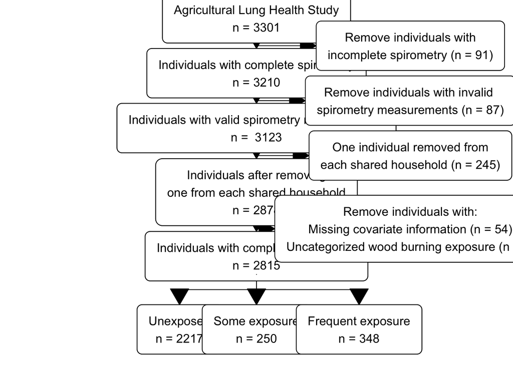

```r
#get file ready to receive image
#jpeg("../Manuscript/FigS1_FlowDiagram.jpg", width=12, height = 8,
#    units = "in", res = 300)

grid.newpage()

midx = 0.5
leftx = 0.25
rightx = 0.8

# A to B1
(a <- boxGrob(paste("Agricultural Lung Health Study",
                    paste("n =", a_num),
                    sep = '\n'), x = midx, y = 0.95))

(b1 <- boxGrob(paste("Individuals with complete spirometry",
                    paste("n =", b1_num), sep = '\n'), x = midx, y = 0.8))
connectGrob(a, b1, "vertical")

# B1 to B2
(b2 <- boxGrob(paste("Remove individuals with",
                     paste0("incomplete spirometry (n = ", b2_num, ")"),
                     sep = '\n'), x = rightx, y = 0.875))
connectGrob(b1, b2, "-")

# B1 to to C1
(c1 <- boxGrob(paste("Individuals with valid spirometry measurements",
                     paste("n = ", c1_num), sep = '\n'),
               x = midx, y = 0.65))
connectGrob(b1, c1, "vertical")

# C1 to C2
(c2 <- boxGrob(paste("Remove individuals with invalid ",
                     paste0("spirometry measurements (n = ", c2_num, ")"),
                     sep = '\n'),
               x = rightx, y = 0.725))
connectGrob(c1, c2, "-")

# C1 to D1
(d1 <- boxGrob(paste("Individuals after removing",
                     "one from each shared household",
                      paste("n =", d1_num), sep = '\n'), x = midx, y = 0.475))
connectGrob(c1, d1, "vertical")

# D1 to D2
(d2 <- boxGrob(paste("One individual removed from",
                     paste0("each shared household (n = ", d2_num, ")"),
                     sep = '\n'), x = rightx, y=0.575))
connectGrob(d1, d2, "-")

# D1 to E1
(e1 <- boxGrob(paste("Individuals with complete information",
                      paste("n =", e1_num), sep = '\n'), x = midx, y = 0.3))
connectGrob(d1, e1, "vertical")

# E1 to E2,3
(e2 <- boxGrob(paste("Remove individuals with:",
                    paste0("Missing covariate information (n = ", e3_num, ")"),
                    paste0("Uncategorized wood burning exposure (n = ", e2_num, ")"),
                    sep = '\n'),
              x = rightx, y = 0.375))
connectGrob(e1, e2, "-")

(ghost <- boxGrob(label = "", x = midx, y = 0.25, width = 0, height = 0))
connectGrob(e1, ghost, "vertical", arrow_obj = arrow(unit(0, "in")))

# D1 to F
(f <- boxGrob(paste("Unexposed", paste("n =", f_num), sep = '\n'), x = 0.35,
                 y = 0.1))
connectGrob(ghost, f, "N")

# D1 to G
(g <- boxGrob(paste("Some exposure", paste("n =", g_num), sep = '\n'),
              x = midx, y = 0.1))
connectGrob(ghost, g, "N")

# D1 to H
(h <- boxGrob(paste("Frequent exposure", paste("n =", h_num),
                    sep = '\n'), x = 0.7, y = 0.1))
connectGrob(ghost, h, "N")

# Print grobs
a
b1
b2
c1
c2
d1
d2
e1
e2
ghost
f
g
h
```

```r
# save and close file
#dev.off()

#clean up
rm(a, b1, b2, c1, c2, d1, d2, e1, e2, ghost, f, g, h, a_num, b1_num, b2_num,
   c1_num, c2_num, d1_num, d2_num, e1_num, e2_num, e3_num, f_num, g_num,
   h_num, leftx, midx, rightx)
```

# Table 1: Study population characteristics

```r
# Variables to go in the table, in order
vars <- c("WoodExp", "gender", "pft_age", "LH_Height", "LH_Weight", "race_B",
          "P1_educ_v3", "state", "LH_smoke_status", "LH_packyears",
          "LHSScreen_12142015", "Im_Atopic_Spec_v2", "P3_COPDorEMPHYSEMA",
          "FTSC_season_v2")

# Creating a special dataframe just for the table so we can re-code the variables
# to be human readable.
tbl_df <- pheno_analysis %>%
  dplyr::select(all_of(vars)) %>%
  mutate(
    WoodExp = recode(WoodExp, `0` = "Unexposed", `1` = "Some exposure",
                     `2` = "Frequent exposure"),
    gender = recode(gender, `0` = "Female", `1` = "Male"),
    state = recode(state, `0` = "Iowa", `1` = "North Carolina"),
    race_B = recode(race_B, `0` = "White", `1` = "Non-white"),
    P1_educ_v3 = recode(P1_educ_v3, `1` = "Up to high school grad",
                        `2` = "More than high school",
                        `3` = "College grad and above"),
    # This next line makes it so that packyears are only calculated for ever
    # smokers, but it introduces NA values so the "Missing" line under packyears
    # was removed from publication tables.
    LH_packyears = case_when(LH_smoke_status == 1 ~ NA_real_,
                             LH_smoke_status %in% c(2,3) ~ LH_packyears),
    LH_smoke_status = recode(LH_smoke_status, `1` = "Never", `2` = "Former",
                             `3` = "Current"),
    LHSScreen_12142015 = recode(LHSScreen_12142015, `0` = "Non-case",
                                `1` = "Case"),
    Im_Atopic_Spec_v2 = recode(Im_Atopic_Spec_v2, `0` = "Non-case", `1` = "Case"),
    P3_COPDorEMPHYSEMA = recode(P3_COPDorEMPHYSEMA, "0) No" = "Non-case",
                                "1) Yes" = "Case"),
    FTSC_season_v2 = recode(FTSC_season_v2,
                            `0` = "Spring (March 21 – June 20)",
                            `1` = "Summer (June 21 – Sept. 20)",
                            `2` = "Fall (Sept. 21 – Dec. 21)",
                            `3` = "Winter (Dec. 22 – March 20)"))

table1_overall <- tbl_summary(
  tbl_df %>% select(-WoodExp) %>%
    mutate(across(.cols = c(P1_educ_v3, Im_Atopic_Spec_v2, P3_COPDorEMPHYSEMA),
                  forcats::fct_explicit_na)),
           missing = "ifany",
           statistic = list(all_continuous() ~ "{mean} ({sd})",
                            all_categorical() ~ "{n} ({p}%)"),
           percent = "col",
           missing_text = "(Missing)",
           label = list(pft_age ~ "Age",
                        gender ~ "Gender",
                        LH_Height ~ "Height (cm)",
                        LH_Weight ~ "Weight (kg)",
                        race_B ~ "Race", state ~ "State",
                        P1_educ_v3 ~ "Education",
                        LH_smoke_status ~ "Smoking status",
                        LH_packyears ~ "Packyears among ever smokers",
                        LHSScreen_12142015 ~ "Asthma status",
                        Im_Atopic_Spec_v2 ~ "Atopy status",
                        P3_COPDorEMPHYSEMA ~ "COPD and/or emphysema status",
                        FTSC_season_v2 ~ "Season")) %>%
    bold_labels() %>%
    italicize_levels()

table1 <- tbl_summary(tbl_df, by = WoodExp, missing = "ifany",
              statistic = list(all_continuous() ~ "{mean} ({sd})",
                               all_categorical() ~ "{n} ({p}%)"),
              percent = "row",
              missing_text = "(Missing)",
              label = list(pft_age ~ "Age",
                           gender ~ "Gender",
                           LH_Height ~ "Height (cm)",
                           LH_Weight ~ "Weight (kg)",
                           race_B ~ "Race", state ~ "State",
                           P1_educ_v3 ~ "Education",
                           LH_smoke_status ~ "Smoking status",
                           LH_packyears ~ "Packyears among ever smokers",
                           LHSScreen_12142015 ~ "Asthma status",
                           Im_Atopic_Spec_v2 ~ "Atopy status",
                           P3_COPDorEMPHYSEMA ~ "COPD and/or emphysema status",
                           FTSC_season_v2 ~ "Season")) %>%
  modify_header(label ~ "**Characteristic**") %>%
  bold_labels() %>%
  italicize_levels() %>%
  add_p(pvalue_fun = ~style_pvalue(.x, digits = 2))

tbl_merge(list(table1_overall, table1),
          tab_spanner = c("Total", "Wood burning exposure")) # %>%
```

| **Characteristic** | Total **N = 2,815**<sup>1</sup> | Wood burning exposure **Unexposed**, N = 2,217<sup>1</sup> | Wood burning exposure **Some exposure**, N = 250<sup>1</sup> | Wood burning exposure **Frequent exposure**, N = 348<sup>1</sup> | Wood burning exposure **p-value**<sup>2</sup> |
| --- | --- | --- | --- | --- | --- |
| Gender |  |  |  |  | 0.10 |
| Female | 1,372 (49%) | 1,098 (80%) | 123 (9.0%) | 151 (11%) |  |
| Male | 1,443 (51%) | 1,119 (78%) | 127 (8.8%) | 197 (14%) |  |
| Age | 63 (11) | 63 (11) | 63 (10) | 62 (11) | 0.67 |
| Height (cm) | 169 (10) | 169 (10) | 169 (9) | 169 (10) | 0.87 |
| Weight (kg) | 87 (20) | 87 (20) | 88 (20) | 86 (20) | 0.24 |
| Race |  |  |  |  | 0.001 |
| White | 2,770 (98%) | 2,187 (79%) | 249 (9.0%) | 334 (12%) |  |
| Non-white | 45 (1.6%) | 30 (67%) | 1 (2.2%) | 14 (31%) |  |
| Education |  |  |  |  | 0.093 |
| Up to high school grad | 1,278 (45%) | 1,010 (79%) | 100 (7.8%) | 168 (13%) |  |
| More than high school | 761 (27%) | 608 (80%) | 62 (8.1%) | 91 (12%) |  |
| College grad and above | 701 (25%) | 549 (78%) | 77 (11%) | 75 (11%) |  |
| (Missing) | 75 (2.7%) |  |  |  |  |
| (Missing) |  | 50 | 11 | 14 |  |
| State |  |  |  |  | <0.001 |
| Iowa | 1,992 (71%) | 1,647 (83%) | 167 (8.4%) | 178 (8.9%) |  |
| North Carolina | 823 (29%) | 570 (69%) | 83 (10%) | 170 (21%) |  |
| Smoking status |  |  |  |  | 0.002 |
| Never | 1,860 (66%) | 1,490 (80%) | 168 (9.0%) | 202 (11%) |  |
| Former | 832 (30%) | 639 (77%) | 74 (8.9%) | 119 (14%) |  |
| Current | 123 (4.4%) | 88 (72%) | 8 (6.5%) | 27 (22%) |  |
| Packyears among ever smokers | 18 (21) | 18 (21) | 15 (18) | 18 (21) | 0.50 |
| (Missing) | 1,860 | 1,490 | 168 | 202 |  |
| Asthma status |  |  |  |  | 0.37 |
| Non-case | 1,732 (62%) | 1,378 (80%) | 145 (8.4%) | 209 (12%) |  |
| Case | 1,083 (38%) | 839 (77%) | 105 (9.7%) | 139 (13%) |  |
| Atopy status |  |  |  |  | 0.10 |
| Non-case | 2,206 (78%) | 1,749 (79%) | 196 (8.9%) | 261 (12%) |  |
| Case | 527 (19%) | 398 (76%) | 49 (9.3%) | 80 (15%) |  |
| (Missing) | 82 (2.9%) |  |  |  |  |
| (Missing) |  | 70 | 5 | 7 |  |
| COPD and/or emphysema status |  |  |  |  | 0.70 |
| Non-case | 2,753 (98%) | 2,169 (79%) | 246 (8.9%) | 338 (12%) |  |
| Case | 59 (2.1%) | 46 (78%) | 4 (6.8%) | 9 (15%) |  |
| (Missing) | 3 (0.1%) |  |  |  |  |
| (Missing) |  | 2 | 0 | 1 |  |
| Season |  |  |  |  | 0.52 |
| Spring (March 21 – June 20) | 727 (26%) | 573 (79%) | 71 (9.8%) | 83 (11%) |  |
| Summer (June 21 – Sept. 20) | 824 (29%) | 648 (79%) | 69 (8.4%) | 107 (13%) |  |
| Fall (Sept. 21 – Dec. 21) | 637 (23%) | 514 (81%) | 47 (7.4%) | 76 (12%) |  |
| Winter (Dec. 22 – March 20) | 627 (22%) | 482 (77%) | 63 (10%) | 82 (13%) |  |

<sup>*1*</sup> n (%); Mean (SD) <sup>*2*</sup> Pearson's Chi-squared test; Kruskal-Wallis rank sum test; Fisher's exact test

```r
  # as_flex_table() %>% print(preview = "docx")

# Clean up
rm(vars, tbl_df, table1, table1_overall)
```

# Table 2 - Survey weighted multivariable results in all subjects

```r
# Get association statistics
# FEV1
covars <- c("pft_age", "pft_age_sq", "gender", "race_B", "LH_Height", "Height_2",
            "state", "LH_smoke_status", "LH_packyears")

multivar_results <- summary(svyglm(formula =
                                     paste0("FEV1_01 ~ WoodExp + ",
                                            paste(covars, collapse = " + ")),
                                   design = pheno_analysis_surv))$coef %>%
  as.data.frame() %>%
  rownames_to_column("Covariate") %>%
  filter(grepl("WoodExp", Covariate)) %>%
  mutate(PFT = "FEV1")

# FVC
fvc_covars <- c("pft_age", "pft_age_sq", "gender", "race_B", "LH_Height",
                "Height_2", "LH_Weight", "state", "LH_smoke_status",
                "LH_packyears")

multivar_results <-
  rbind(multivar_results,
        summary(svyglm(formula = paste0("FVC_01 ~ WoodExp + ",
                                        paste(fvc_covars, collapse = " + ")),
                       design = pheno_analysis_surv))$coef %>%
          as.data.frame() %>%
          rownames_to_column("Covariate") %>%
          filter(grepl("WoodExp", Covariate)) %>%
          mutate(PFT = "FVC"))

# Ratio
multivar_results <-
  rbind(multivar_results,
        summary(svyglm(formula =
                         paste0("RATIO1_01_r ~ WoodExp + ",
                                paste(covars, collapse = " + ")),
                       design = pheno_analysis_surv))$coef %>%
          as.data.frame() %>%
          rownames_to_column("Covariate") %>%
          filter(grepl("WoodExp", Covariate)) %>%
          mutate(PFT = "Ratio"))

# Write the association statistics part of table 2
multivar_results %>%
  mutate(Covariate = str_replace_all(Covariate, c("WoodExp1" = "Some",
                                                  "WoodExp2" = "Frequent")),
         LowCI = Estimate - (1.96 * `Std. Error`),
         HighCI = Estimate + (1.96 * `Std. Error`)) %>%
  mutate(Estimate = case_when(PFT %in% c("FEV1", "FVC") ~ round(Estimate, digits = 0),
                                 PFT == "Ratio" ~ signif(Estimate, digits = 1)),
         LowCI = case_when(PFT %in% c("FEV1", "FVC") ~ round(LowCI, digits = 0),
                              PFT == "Ratio" ~ signif(LowCI, digits = 1)),
         HighCI = case_when(PFT %in% c("FEV1", "FVC") ~ round(HighCI, digits = 0),
                               PFT == "Ratio" ~ signif(HighCI, digits = 1))) %>%
  rename(P = `Pr(>|t|)`) %>%
  dplyr::select(PFT, Covariate, Estimate, LowCI, HighCI) %>%
  mutate(LowCI = paste0("(", LowCI),
         HighCI = paste0(HighCI, ")")) %>%
  unite(col = CI, c(LowCI, HighCI), sep = ", ", remove = TRUE) %>%
  unite(col = Estimate, c(Estimate, CI), sep = "\n", remove = TRUE) %>%
  pivot_wider(names_from = PFT, values_from = Estimate) %>%
  dplyr::select(Covariate, starts_with("FEV1"), starts_with("FVC"),
                starts_with("Ratio")) %>%
  flextable() %>%
  theme_box() %>%
  autofit() %>%
  align(align = "center", part = "all") #%>% print(preview = "docx")
```

| Covariate | FEV1 | FVC | Ratio |
| --- | --- | --- | --- |
| Some | -3 (-78, 72) | 30 (-61, 122) | -0.2 (-1, 0.9) |
| Frequent | -5 (-72, 63) | -12 (-92, 68) | -0.4 (-1, 0.6) |

Weighted average and SD for PFTs across groups. Tje N’s listed in the header are weighted Ns (default of the function). In the manuscript we report unweighted Ns.

```r
tbl_svysummary(by = WoodExp, missing = "ifany",
               statistic = list(all_continuous() ~ "{mean} ({sd})"),
               label = list(FEV1_01 ~ "FEV1",
                            FVC_01 ~ "FVC",
                            RATIO1_01_r ~ "FEV1/FVC"),
               data = pheno_analysis_surv,
               include = c("FEV1_01", "FVC_01","RATIO1_01_r", "WoodExp"))
```

| **Characteristic** | **0**, N = 2,236<sup>1</sup> | **1**, N = 238<sup>1</sup> | **2**, N = 341<sup>1</sup> |
| --- | --- | --- | --- |
| FEV1 | 2,666 (813) | 2,660 (783) | 2,661 (813) |
| FVC | 3,584 (1,007) | 3,595 (1,019) | 3,605 (1,013) |
| FEV1/FVC | 74 (8) | 74 (8) | 74 (9) |

<sup>*1*</sup> Mean (SD)

Unweighted Ns by group

```r
table(pheno_analysis_surv$variables$WoodExp, useNA = "ifany")
```

```
##
##    0    1    2
## 2217  250  348
```

# Table S2: Unweighted multivariable results in all subjects

```r
# Association statistics
# FEV1
multivar_results <-
  summary(lm(formula = paste0("FEV1_01 ~ WoodExp + ",
                              paste(covars, collapse = " + ")),
             data = pheno_analysis))$coef %>%
  as.data.frame() %>%
  rownames_to_column("Covariate") %>%
  filter(grepl("WoodExp", Covariate)) %>%
  mutate(PFT = "FEV1")

# FVC
multivar_results <-
  rbind(multivar_results,
        summary(lm(formula = paste0("FVC_01 ~ WoodExp + ",
                                    paste(fvc_covars, collapse = " + ")),
                   data = pheno_analysis))$coef %>%
          as.data.frame() %>%
          rownames_to_column("Covariate") %>%
          filter(grepl("WoodExp", Covariate)) %>%
          mutate(PFT = "FVC"))

# Ratio
multivar_results <-
  rbind(multivar_results,
        summary(lm(formula = paste0("RATIO1_01_r ~ WoodExp + ",
                                    paste(covars, collapse = " + ")),
                   data = pheno_analysis))$coef %>%
          as.data.frame() %>%
          rownames_to_column("Covariate") %>%
          filter(grepl("WoodExp", Covariate)) %>%
          mutate(PFT = "Ratio"))

# Write association stats part of Table S2
multivar_results %>%
  mutate(Covariate = str_replace_all(Covariate, c("WoodExp1" = "Some",
                                                  "WoodExp2" = "Frequent")),
         LowCI = Estimate - (1.96 * `Std. Error`),
         HighCI = Estimate + (1.96 * `Std. Error`)) %>%
  mutate(Estimate = case_when(PFT %in% c("FEV1", "FVC") ~ round(Estimate, digits = 0),
                                 PFT == "Ratio" ~ signif(Estimate, digits = 1)),
         LowCI = case_when(PFT %in% c("FEV1", "FVC") ~ round(LowCI, digits = 0),
                              PFT == "Ratio" ~ signif(LowCI, digits = 1)),
         HighCI = case_when(PFT %in% c("FEV1", "FVC") ~ round(HighCI, digits = 0),
                               PFT == "Ratio" ~ signif(HighCI, digits = 1))) %>%
  rename(P = `Pr(>|t|)`) %>%
  dplyr::select(PFT, Covariate, Estimate, LowCI, HighCI) %>%
  mutate(LowCI = paste0("(", LowCI),
         HighCI = paste0(HighCI, ")")) %>%
  unite(col = CI, c(LowCI, HighCI), sep = ", ", remove = TRUE) %>%
  unite(col = Estimate, c(Estimate, CI), sep = "\n", remove = TRUE) %>%
  pivot_wider(names_from = PFT, values_from = Estimate) %>%
  dplyr::select(Covariate, starts_with("FEV1"), starts_with("FVC"),
                starts_with("Ratio")) %>%
  flextable() %>%
  theme_box() %>%
  autofit() %>%
  align(align = "center", part = "all") #%>% print(preview = "docx")
```

| Covariate | FEV1 | FVC | Ratio |
| --- | --- | --- | --- |
| Some | -16 (-83, 52) | 1 (-73, 75) | -0.4 (-1, 0.7) |
| Frequent | -65 (-124, -6) | -54 (-119, 11) | -1 (-2, -0.2) |

Unweighted average and SD for PFTs across groups:

```r
tbl_summary(by = WoodExp, missing = "ifany",
               statistic = list(all_continuous() ~ "{mean} ({sd})"),
               label = list(FEV1_01 ~ "FEV1",
                            FVC_01 ~ "FVC",
                            RATIO1_01_r ~ "FEV1/FVC"),
               data = pheno_analysis,
               include = c("FEV1_01", "FVC_01","RATIO1_01_r", "WoodExp"))
```

| **Characteristic** | **0**, N = 2,217<sup>1</sup> | **1**, N = 250<sup>1</sup> | **2**, N = 348<sup>1</sup> |
| --- | --- | --- | --- |
| FEV1 | 2,572 (824) | 2,556 (825) | 2,529 (805) |
| FVC | 3,503 (1,020) | 3,495 (1,048) | 3,494 (975) |
| FEV1/FVC | 73 (9) | 73 (9) | 72 (11) |

<sup>*1*</sup> Mean (SD)

# Table S3: Sample weighted multivariable association results for individuals sampled in the cold season

```r
# Subset our survey design object to people visited in the cold season
tmp <- subset(pheno_analysis_surv, lubridate::month(FTSC_DATE) %in% c(1,2,3,4,11,12))

# Association statistics
# FEV1
multivar_results <- summary(svyglm(formula =
                                     paste0("FEV1_01 ~ WoodExp + ",
                                            paste(covars, collapse = " + ")),
                                   design = tmp))$coef %>%
  as.data.frame() %>%
  rownames_to_column("Covariate") %>%
  filter(grepl("WoodExp", Covariate)) %>%
  mutate(PFT = "FEV1")

# FVC
multivar_results <-
  rbind(multivar_results,
        summary(svyglm(formula = paste0("FVC_01 ~ WoodExp + ",
                                        paste(fvc_covars, collapse = " + ")),
                       design = tmp))$coef %>%
          as.data.frame() %>%
          rownames_to_column("Covariate") %>%
          filter(grepl("WoodExp", Covariate)) %>%
          mutate(PFT = "FVC"))

# Ratio
multivar_results <- rbind(multivar_results, summary(svyglm(formula =
                                     paste0("RATIO1_01_r ~ WoodExp + ",
                                            paste(covars, collapse = " + ")),
                                   design = tmp))$coef %>%
  as.data.frame() %>%
  rownames_to_column("Covariate") %>%
  filter(grepl("WoodExp", Covariate)) %>%
  mutate(PFT = "Ratio"))

# Write table
multivar_results %>%
  mutate(Covariate = str_replace_all(Covariate, c("WoodExp1" = "Some",
                                                  "WoodExp2" = "Frequent")),
         LowCI = Estimate - (1.96 * `Std. Error`),
         HighCI = Estimate + (1.96 * `Std. Error`)) %>%
  mutate(Estimate = case_when(PFT %in% c("FEV1", "FVC") ~ round(Estimate, digits = 0),
                                 PFT == "Ratio" ~ signif(Estimate, digits = 1)),
         LowCI = case_when(PFT %in% c("FEV1", "FVC") ~ round(LowCI, digits = 0),
                              PFT == "Ratio" ~ signif(LowCI, digits = 1)),
         HighCI = case_when(PFT %in% c("FEV1", "FVC") ~ round(HighCI, digits = 0),
                               PFT == "Ratio" ~ signif(HighCI, digits = 1))) %>%
  rename(P = `Pr(>|t|)`) %>%
  dplyr::select(PFT, Covariate, Estimate, LowCI, HighCI) %>%
  mutate(LowCI = paste0("(", LowCI),
         HighCI = paste0(HighCI, ")")) %>%
  unite(col = CI, c(LowCI, HighCI), sep = ", ", remove = TRUE) %>%
  unite(col = Estimate, c(Estimate, CI), sep = "\n", remove = TRUE) %>%
  pivot_wider(names_from = PFT, values_from = Estimate) %>%
  dplyr::select(Covariate, starts_with("FEV1"), starts_with("FVC"),
                starts_with("Ratio")) %>%
  flextable() %>%
  theme_box() %>%
  autofit() %>%
  align(align = "center", part = "all") #%>% print(preview = "docx")
```

| Covariate | FEV1 | FVC | Ratio |
| --- | --- | --- | --- |
| Some | 58 (-39, 156) | 89 (-42, 220) | 0.4 (-1, 2) |
| Frequent | -8 (-103, 87) | 5 (-103, 113) | -0.7 (-2, 0.7) |

Weighted average and SD for PFTs across groups. Tje N’s listed in the header are weighted Ns (default of the function). In the manuscript we report unweighted Ns.

```r
tbl_svysummary(by = WoodExp, missing = "ifany",
               statistic = list(all_continuous() ~ "{mean} ({sd})"),
               label = list(FEV1_01 ~ "FEV1",
                            FVC_01 ~ "FVC",
                            RATIO1_01_r ~ "FEV1/FVC"),
               data = tmp,
               include = c("FEV1_01", "FVC_01","RATIO1_01_r", "WoodExp"))
```

| **Characteristic** | **0**, N = 1,048<sup>1</sup> | **1**, N = 108<sup>1</sup> | **2**, N = 158<sup>1</sup> |
| --- | --- | --- | --- |
| FEV1 | 2,678 (814) | 2,720 (767) | 2,725 (745) |
| FVC | 3,597 (992) | 3,652 (1,049) | 3,695 (919) |
| FEV1/FVC | 74 (8) | 75 (8) | 74 (9) |

<sup>*1*</sup> Mean (SD)

Unweighted Ns:

```r
table(tmp$variables$WoodExp, useNA = "ifany")
```

```
##
##    0    1    2
## 1009  118  158
```

# Table S4: Weighted multivariable association results for individuals identified as “White”

```r
# Subset the survey design object
tmp <- subset(pheno_analysis_surv, race_B == 0)

# Association statstics
# FEV1
multivar_results <- summary(svyglm(formula =
                                     paste0("FEV1_01 ~ WoodExp + ",
                                            paste(covars[-which(covars == "race_B")],
                                                  collapse = " + ")),
                                   design = tmp))$coef %>%
  as.data.frame() %>%
  rownames_to_column("Covariate") %>%
  filter(grepl("WoodExp", Covariate)) %>%
  mutate(PFT = "FEV1")

# FVC
multivar_results <-
  rbind(multivar_results,
        summary(svyglm(formula = paste0("FVC_01 ~ WoodExp + ",
                                        paste(fvc_covars[-which(fvc_covars == "race_B")],
                                              collapse = " + ")),
                       design = tmp))$coef %>%
          as.data.frame() %>%
          rownames_to_column("Covariate") %>%
          filter(grepl("WoodExp", Covariate)) %>%
          mutate(PFT = "FVC"))

# Ratio
multivar_results <-
  rbind(multivar_results, summary(svyglm(formula =
                                           paste0("RATIO1_01_r ~ WoodExp + ",
                                                  paste(covars[-which(covars == "race_B")],
                                                        collapse = " + ")),
                                         design = tmp))$coef %>%
          as.data.frame() %>%
          rownames_to_column("Covariate") %>%
          filter(grepl("WoodExp", Covariate)) %>%
          mutate(PFT = "Ratio"))

# Write table:
multivar_results %>%
  mutate(Covariate = str_replace_all(Covariate, c("WoodExp1" = "Some",
                                                  "WoodExp2" = "Frequent")),
         LowCI = Estimate - (1.96 * `Std. Error`),
         HighCI = Estimate + (1.96 * `Std. Error`)) %>%
  mutate(Estimate = case_when(PFT %in% c("FEV1", "FVC") ~ round(Estimate, digits = 0),
                                 PFT == "Ratio" ~ signif(Estimate, digits = 1)),
         LowCI = case_when(PFT %in% c("FEV1", "FVC") ~ round(LowCI, digits = 0),
                              PFT == "Ratio" ~ signif(LowCI, digits = 1)),
         HighCI = case_when(PFT %in% c("FEV1", "FVC") ~ round(HighCI, digits = 0),
                               PFT == "Ratio" ~ signif(HighCI, digits = 1))) %>%
  rename(P = `Pr(>|t|)`) %>%
  dplyr::select(PFT, Covariate, Estimate, LowCI, HighCI) %>%
  mutate(LowCI = paste0("(", LowCI),
         HighCI = paste0(HighCI, ")")) %>%
  unite(col = CI, c(LowCI, HighCI), sep = ", ", remove = TRUE) %>%
  unite(col = Estimate, c(Estimate, CI), sep = "\n", remove = TRUE) %>%
  pivot_wider(names_from = PFT, values_from = Estimate) %>%
  dplyr::select(Covariate, starts_with("FEV1"), starts_with("FVC"),
                starts_with("Ratio")) %>%
  flextable() %>%
  theme_box() %>%
  autofit() %>%
  align(align = "center", part = "all") #%>% print(preview = "docx")
```

| Covariate | FEV1 | FVC | Ratio |
| --- | --- | --- | --- |
| Some | -7 (-82, 68) | 26 (-66, 117) | -0.2 (-1, 0.9) |
| Frequent | -1 (-69, 68) | -8 (-89, 73) | -0.4 (-1, 0.5) |

Weighted average and SD for PFTs across groups. Tje N’s listed in the header are weighted Ns (default of the function). In the manuscript we report unweighted Ns.

```r
tbl_svysummary(by = WoodExp, missing = "ifany",
               statistic = list(all_continuous() ~ "{mean} ({sd})"),
               label = list(FEV1_01 ~ "FEV1",
                            FVC_01 ~ "FVC",
                            RATIO1_01_r ~ "FEV1/FVC"),
               data = tmp,
               include = c("FEV1_01", "FVC_01","RATIO1_01_r", "WoodExp"))
```

| **Characteristic** | **0**, N = 2,204<sup>1</sup> | **1**, N = 237<sup>1</sup> | **2**, N = 327<sup>1</sup> |
| --- | --- | --- | --- |
| FEV1 | 2,670 (816) | 2,663 (784) | 2,678 (818) |
| FVC | 3,589 (1,010) | 3,601 (1,020) | 3,629 (1,018) |
| FEV1/FVC | 74 (8) | 74 (8) | 74 (9) |

<sup>*1*</sup> Mean (SD)

Unweighted Ns:

```r
table(tmp$variables$WoodExp, useNA = "ifany")
```

```
##
##    0    1    2
## 2187  249  334
```

# Table S5: Sample weighted multivariable association by smoking status

```r
# Analysis results
contrast_list <- list("Some-Former" = c("WoodExpSmokingIntUnexp-Former"=-1,
                                        "WoodExpSmokingIntSome-Former"=1),
                      "Freq-Former" = c("WoodExpSmokingIntUnexp-Former"=-1,
                                        "WoodExpSmokingIntFreq-Former"=1),
                      "Some-Current" = c("WoodExpSmokingIntUnexp-Current"=-1,
                                         "WoodExpSmokingIntSome-Current"=1),
                      "Freq-Current" = c("WoodExpSmokingIntUnexp-Current"=-1,
                                         "WoodExpSmokingIntFreq-Current"=1))

# FEV1
fev1_mod <- svyglm(formula = paste0("FEV1_01 ~ ",
                                    paste(covars[-which(covars == "LH_smoke_status")],
                                          collapse = " + "), "+ WoodExpSmokingInt"),
                   design = pheno_analysis_surv)

fev1_results <-
  rbind(summary(fev1_mod)$coef %>%
          as.data.frame() %>%
          rownames_to_column("Covariate") %>%
          filter(grepl("Never", Covariate)) %>%
          mutate(Covariate = str_replace(Covariate, "WoodExpSmokingInt", "")) %>%
          rename(SE = `Std. Error`, T = `t value`, P = `Pr(>|t|)`),
        as_tibble(svycontrast(fev1_mod, contrasts = contrast_list),
                  rownames = NA) %>%
          rownames_to_column("Covariate") %>%
          rename(Estimate = contrast) %>%
          mutate(T = Estimate/SE,
                 P = 2 * pt(abs(T), df = df.residual(fev1_mod), lower.tail = FALSE))) %>%
  mutate(PFT = "FEV1")

# FVC
fvc_mod <- svyglm(formula = paste0("FVC_01 ~ ",
                                   paste(fvc_covars[-which(fvc_covars == "LH_smoke_status")],
                                         collapse = " + "), "+ WoodExpSmokingInt"),
                   design = pheno_analysis_surv)

fvc_results <-
  rbind(summary(fvc_mod)$coef %>%
          as.data.frame() %>%
          rownames_to_column("Covariate") %>%
          filter(grepl("Never", Covariate)) %>%
          mutate(Covariate = str_replace(Covariate, "WoodExpSmokingInt", "")) %>%
          rename(SE = `Std. Error`, T = `t value`, P = `Pr(>|t|)`),
        as_tibble(svycontrast(fvc_mod, contrasts = contrast_list),
                  rownames = NA) %>%
          rownames_to_column("Covariate") %>%
          rename(Estimate = contrast) %>%
          mutate(T = Estimate/SE,
                 P = 2 * pt(abs(T), df = df.residual(fvc_mod), lower.tail = FALSE))) %>%
  mutate(PFT = "FVC")

# Ratio
ratio_mod <- svyglm(formula = paste0("RATIO1_01_r ~ ",
                                     paste(covars[-which(covars == "LH_smoke_status")],
                                           collapse = " + "), "+ WoodExpSmokingInt"),
                   design = pheno_analysis_surv)

ratio_results <-
  rbind(summary(ratio_mod)$coef %>%
          as.data.frame() %>%
          rownames_to_column("Covariate") %>%
          filter(grepl("Never", Covariate)) %>%
          mutate(Covariate = str_replace(Covariate, "WoodExpSmokingInt", "")) %>%
          rename(SE = `Std. Error`, T = `t value`, P = `Pr(>|t|)`),
        as_tibble(svycontrast(ratio_mod, contrasts = contrast_list),
                  rownames = NA) %>%
          rownames_to_column("Covariate") %>%
          rename(Estimate = contrast) %>%
          mutate(T = Estimate/SE,
                 P = 2 * pt(abs(T), df = df.residual(ratio_mod), lower.tail = FALSE))) %>%
  mutate(PFT = "Ratio")

# Make table:
multivar_results <- rbind(fev1_results, fvc_results, ratio_results)

multivar_results %>%
  separate(col = Covariate, into = c("WoodExp", "Smoking"), sep = "-") %>%
  mutate(LowCI = Estimate - (1.96 * SE),
         HighCI = Estimate + (1.96 * SE),
         Estimate = case_when(PFT %in% c("FEV1", "FVC") ~ round(Estimate, digits = 0),
                                 PFT == "Ratio" ~ signif(Estimate, digits = 1)),
         LowCI = case_when(PFT %in% c("FEV1", "FVC") ~ round(LowCI, digits = 0),
                              PFT == "Ratio" ~ signif(LowCI, digits = 1)),
         HighCI = case_when(PFT %in% c("FEV1", "FVC") ~ round(HighCI, digits = 0),
                               PFT == "Ratio" ~ signif(HighCI, digits = 1))) %>%
  dplyr::select(PFT, WoodExp, Smoking, Estimate, LowCI, HighCI) %>%
  mutate(LowCI = paste0("(", LowCI),
         HighCI = paste0(HighCI, ")")) %>%
  unite(col = CI, c(LowCI, HighCI), sep = ", ", remove = TRUE) %>%
  unite(col = Estimate, c(Estimate, CI), sep = "\n", remove = TRUE) %>%
  pivot_wider(names_from = PFT, values_from = Estimate) %>%
  dplyr::select(WoodExp, Smoking, starts_with("FEV1"), starts_with("FVC"),
                starts_with("Ratio")) %>%
  flextable() %>%
  theme_box() %>%
  autofit() %>%
  align(align = "center", part = "all") #%>% print(preview = "docx")
```

| WoodExp | Smoking | FEV1 | FVC | Ratio |
| --- | --- | --- | --- | --- |
| Some | Never | -16 (-100, 69) | 3 (-104, 109) | -0.3 (-2, 1) |
| Freq | Never | 15 (-67, 97) | -3 (-106, 100) | 0.06 (-0.9, 1) |
| Some | Former | 25 (-132, 182) | 111 (-80, 303) | -0.3 (-3, 2) |
| Freq | Former | -9 (-128, 110) | 14 (-118, 145) | -0.7 (-3, 1) |
| Some | Current | 11 (-476, 497) | -77 (-430, 276) | 2 (-6, 10) |
| Freq | Current | -119 (-419, 181) | -173 (-497, 151) | -2 (-8, 3) |

Sample sizes by wood burning exposure and smoking status

```r
fev1_mod$model %>% group_by(WoodExpSmokingInt) %>% summarize(N = n())
```

```
## # A tibble: 9 × 2
##   WoodExpSmokingInt     N
##   <fct>             <int>
## 1 Unexp-Never        1490
## 2 Some-Never          168
## 3 Freq-Never          202
## 4 Unexp-Former        639
## 5 Some-Former          74
## 6 Freq-Former         119
## 7 Unexp-Current        88
## 8 Some-Current          8
## 9 Freq-Current         27
```

# Figure S2: Predicted values by wood burning and smoking status

```r
# Data frame that will be used to store the predicted values
pred_df_smoking <- tibble(
  pft_age = svymean(~pft_age, design = pheno_analysis_surv)[1],
  pft_age_sq = svymean(~pft_age, design = pheno_analysis_surv)[1]^2,
  gender = factor(0),
  race_B = factor(0),
  LH_Height = svymean(~LH_Height, design = pheno_analysis_surv)[1],
  Height_2 = svymean(~LH_Height, design = pheno_analysis_surv)[1]^2,
  LH_Weight = svymean(~LH_Weight, design = pheno_analysis_surv)[1],
  state = factor(0),
  LH_packyears = svymean(~LH_packyears, design = pheno_analysis_surv)[1],
  LH_smoke_status = factor(c(1,1,1,2,2,2,3,3,3)),
  WoodExp = factor(c(0,1,2,0,1,2,0,1,2))
)

# FEV1
# Association results, this time with the interaction modeled using *
fev1_mod <- svyglm(formula = paste0("FEV1_01 ~ WoodExp + ",
                                    paste(covars, collapse = " + "),
                                    " + WoodExp*LH_smoke_status"),
                   design = pheno_analysis_surv)

# Predict and add to prediction df
pred_df_smoking <- cbind(pred_df_smoking, predict(fev1_mod, pred_df_smoking)) %>%
  unite("FEV1", link:SE)

# FVC
fvc_mod <- svyglm(formula = paste0("FVC_01 ~ WoodExp + ",
                             paste(fvc_covars, collapse = " + "),
                             " + WoodExp*LH_smoke_status"),
            design = pheno_analysis_surv)

pred_df_smoking <-  cbind(pred_df_smoking, predict(fvc_mod, pred_df_smoking)) %>%
  unite("FVC", link:SE)

# Ratio
ratio_mod <- svyglm(formula = paste0("RATIO1_01_r ~ WoodExp + ",
                                     paste(covars, collapse = " + "),
                                     " + WoodExp*LH_smoke_status"),
                    design = pheno_analysis_surv)

pred_df_smoking <-  cbind(pred_df_smoking, predict(ratio_mod, pred_df_smoking)) %>%
  unite("Ratio", link:SE)
```

Plot:

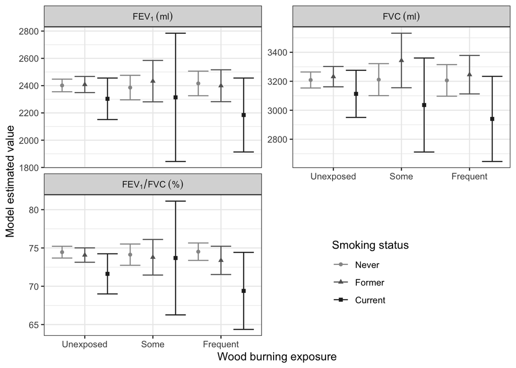

```r
pred_df_smoking %>%
  select(WoodExp, LH_smoke_status, FEV1, FVC, Ratio) %>%
  pivot_longer(cols = FEV1:Ratio, names_to = "PFT") %>%
  mutate(PFT = factor(PFT, levels = c("FEV1", "FVC", "Ratio"),
                      labels = c("FEV[1]~(ml)", "FVC~(ml)", "FEV[1]/FVC~('%')"))) %>%
  separate(value, into = c("Pred", "SE"), sep = "_") %>%
  mutate(Pred = as.numeric(Pred), SE = as.numeric(SE)) %>%
  mutate(LowCI = Pred - (1.96*SE), HighCI = Pred + (1.96*SE)) %>%
  select(-SE) %>%
  ggplot(aes(x = WoodExp, y = Pred, ymin = LowCI, ymax = HighCI,
             color = LH_smoke_status, shape = LH_smoke_status)) +
  geom_point(position = position_dodge(width = 1)) +
  geom_errorbar(position = position_dodge(width = 1)) +
  facet_wrap(~PFT, nrow = 2, scales = "free_y", labeller = label_parsed) +
  labs(x = "Wood burning exposure", y = "Model estimated value",
       color = "Smoking status", shape = "Smoking status") +
  scale_x_discrete(labels = c("Unexposed", "Some", "Frequent")) +
  scale_color_manual(values =
                       RColorBrewer::brewer.pal(n = 5, name = "Greys")[c(3:5)],
                     labels = c("Never", "Former", "Current")) +
  scale_shape_manual(values = c(16, 17, 15), labels = c("Never", "Former", "Current")) +
  theme_bw() + theme(legend.position = c(0.7,0.2))
```

```r
#ggsave(filename = "../Manuscript/FigS2_Woodburning_Smoking_Interaction_Plot.jpg",
#       plot = last_plot(), device = "jpg", width = 6.5, height = 6.5, dpi = 300)
```

# Table S6: Unweighted multiariable associations by smoking status

```r
# Association results
# FEV1
fev1_mod <- lm(formula = paste0("FEV1_01 ~ ",
                                paste(covars[-which(covars == "LH_smoke_status")],
                                      collapse = " + "), "+ WoodExpSmokingInt"),
               data = pheno_analysis)

fev1_results <-
  rbind(summary(fev1_mod)$coef %>%
          as.data.frame() %>%
          rownames_to_column("Covariate") %>%
          filter(grepl("Never", Covariate)) %>%
          mutate(Covariate = str_replace(Covariate, "WoodExpSmokingInt", "")) %>%
          rename(SE = `Std. Error`, T = `t value`, P = `Pr(>|t|)`),
        as_tibble(svycontrast(fev1_mod, contrasts = contrast_list),
                  rownames = NA) %>%
          rownames_to_column("Covariate") %>%
          rename(Estimate = contrast) %>%
          mutate(T = Estimate/SE,
                 P = 2 * pt(abs(T), df = df.residual(fev1_mod),
                            lower.tail = FALSE))) %>%
  mutate(PFT = "FEV1")

# FVC
fvc_mod <- lm(formula = paste0("FVC_01 ~ ",
                               paste(fvc_covars[-which(fvc_covars == "LH_smoke_status")],
                                     collapse = " + "), "+ WoodExpSmokingInt"),
              data = pheno_analysis)

fvc_results <-
  rbind(summary(fvc_mod)$coef %>%
          as.data.frame() %>%
          rownames_to_column("Covariate") %>%
          filter(grepl("Never", Covariate)) %>%
          mutate(Covariate = str_replace(Covariate, "WoodExpSmokingInt", "")) %>%
          rename(SE = `Std. Error`, T = `t value`, P = `Pr(>|t|)`),
        as_tibble(svycontrast(fvc_mod, contrasts = contrast_list),
                  rownames = NA) %>%
          rownames_to_column("Covariate") %>%
          rename(Estimate = contrast) %>%
          mutate(T = Estimate/SE,
                 P = 2 * pt(abs(T), df = df.residual(fvc_mod),
                            lower.tail = FALSE))) %>%
  mutate(PFT = "FVC")

# Ratio
ratio_mod <- lm(formula = paste0("RATIO1_01_r ~ ",
                                 paste(covars[-which(covars == "LH_smoke_status")],
                                       collapse = " + "), "+ WoodExpSmokingInt"),
                data = pheno_analysis)

ratio_results <-
  rbind(summary(ratio_mod)$coef %>%
          as.data.frame() %>%
          rownames_to_column("Covariate") %>%
          filter(grepl("Never", Covariate)) %>%
          mutate(Covariate = str_replace(Covariate, "WoodExpSmokingInt", "")) %>%
          rename(SE = `Std. Error`, T = `t value`, P = `Pr(>|t|)`),
        as_tibble(svycontrast(ratio_mod, contrasts = contrast_list),
                  rownames = NA) %>%
          rownames_to_column("Covariate") %>%
          rename(Estimate = contrast) %>%
          mutate(T = Estimate/SE,
                 P = 2 * pt(abs(T), df = df.residual(ratio_mod),
                            lower.tail = FALSE))) %>%
  mutate(PFT = "Ratio")

# Make table
multivar_results <- rbind(fev1_results, fvc_results, ratio_results)

multivar_results %>%
  separate(col = Covariate, into = c("WoodExp", "Smoking"), sep = "-") %>%
  mutate(LowCI = Estimate - (1.96 * SE),
         HighCI = Estimate + (1.96 * SE),
         Estimate = case_when(PFT %in% c("FEV1", "FVC") ~ round(Estimate, digits = 0),
                              PFT == "Ratio" ~ signif(Estimate, digits = 1)),
         LowCI = case_when(PFT %in% c("FEV1", "FVC") ~ round(LowCI, digits = 0),
                           PFT == "Ratio" ~ signif(LowCI, digits = 1)),
         HighCI = case_when(PFT %in% c("FEV1", "FVC") ~ round(HighCI, digits = 0),
                            PFT == "Ratio" ~ signif(HighCI, digits = 1))) %>%
  dplyr::select(PFT, WoodExp, Smoking, Estimate, LowCI, HighCI) %>%
  mutate(LowCI = paste0("(", LowCI),
         HighCI = paste0(HighCI, ")")) %>%
  unite(col = CI, c(LowCI, HighCI), sep = ", ", remove = TRUE) %>%
  unite(col = Estimate, c(Estimate, CI), sep = "\n", remove = TRUE) %>%
  pivot_wider(names_from = PFT, values_from = Estimate) %>%
  dplyr::select(WoodExp, Smoking, starts_with("FEV1"), starts_with("FVC"),
                starts_with("Ratio")) %>%
  flextable() %>%
  theme_box() %>%
  autofit() %>%
  align(align = "center", part = "all") #%>% print(preview = "docx")
```

| WoodExp | Smoking | FEV1 | FVC | Ratio |
| --- | --- | --- | --- | --- |
| Some | Never | -29 (-110, 53) | -24 (-114, 67) | -0.5 (-2, 0.8) |
| Freq | Never | -56 (-132, 20) | -67 (-151, 16) | -0.3 (-1, 1) |
| Some | Former | 12 (-112, 135) | 61 (-75, 198) | 0.07 (-2, 2) |
| Freq | Former | -51 (-152, 50) | 5 (-106, 117) | -2 (-4, -0.4) |
| Some | Current | 11 (-360, 383) | -29 (-438, 380) | -0.9 (-7, 5) |
| Freq | Current | -202 (-423, 20) | -211 (-455, 33) | -4 (-8, -0.7) |

Sample sizes by wood burning x smoking group

```r
fev1_mod$model %>% group_by(WoodExpSmokingInt) %>% summarize(N = n())
```

```
## # A tibble: 9 × 2
##   WoodExpSmokingInt     N
##   <fct>             <int>
## 1 Unexp-Never        1490
## 2 Some-Never          168
## 3 Freq-Never          202
## 4 Unexp-Former        639
## 5 Some-Former          74
## 6 Freq-Former         119
## 7 Unexp-Current        88
## 8 Some-Current          8
## 9 Freq-Current         27
```

# Table 3: Sample weighted multivariable results by asthma status

```r
# Association statistics
contrast_list <- list("Some-Case" = c("WoodExpAsthmaIntUnexp-Case"=-1,
                                      "WoodExpAsthmaIntSome-Case"=1),
                      "Freq-Case" = c("WoodExpAsthmaIntUnexp-Case"=-1,
                                      "WoodExpAsthmaIntFreq-Case"=1))

# FEV1
fev1_mod <- svyglm(formula = paste0("FEV1_01 ~ ",
                                    paste(covars, collapse = " + "),
                                    "+ WoodExpAsthmaInt"),
                   design = pheno_analysis_surv)

fev1_results <-
  rbind(summary(fev1_mod)$coef %>%
          as.data.frame() %>%
          rownames_to_column("Covariate") %>%
          filter(grepl("Noncase", Covariate)) %>%
          mutate(Covariate = str_replace(Covariate, "WoodExpAsthmaInt", "")) %>%
          rename(SE = `Std. Error`, T = `t value`, P = `Pr(>|t|)`),
        as_tibble(svycontrast(fev1_mod, contrasts = contrast_list),
                  rownames = NA) %>%
          rownames_to_column("Covariate") %>%
          rename(Estimate = contrast) %>%
          mutate(T = Estimate/SE,
                 P = 2 * pt(abs(T), df = df.residual(fev1_mod),
                            lower.tail = FALSE))) %>%
  mutate(PFT = "FEV1")

# FVC
fvc_mod <- svyglm(formula = paste0("FVC_01 ~ ",
                                   paste(fvc_covars, collapse = " + "),
                                   "+ WoodExpAsthmaInt"),
                   design = pheno_analysis_surv)

fvc_results <-
  rbind(summary(fvc_mod)$coef %>%
          as.data.frame() %>%
          rownames_to_column("Covariate") %>%
          filter(grepl("Noncase", Covariate)) %>%
          mutate(Covariate = str_replace(Covariate, "WoodExpAsthmaInt", "")) %>%
          rename(SE = `Std. Error`, T = `t value`, P = `Pr(>|t|)`),
        as_tibble(svycontrast(fvc_mod, contrasts = contrast_list),
                  rownames = NA) %>%
          rownames_to_column("Covariate") %>%
          rename(Estimate = contrast) %>%
          mutate(T = Estimate/SE,
                 P = 2 * pt(abs(T), df = df.residual(fvc_mod),
                            lower.tail = FALSE))) %>%
  mutate(PFT = "FVC")

# Ratio
ratio_mod <- svyglm(formula = paste0("RATIO1_01_r ~ ",
                                     paste(covars, collapse = " + "),
                                     "+ WoodExpAsthmaInt"),
                   design = pheno_analysis_surv)

ratio_results <-
  rbind(summary(ratio_mod)$coef %>%
          as.data.frame() %>%
          rownames_to_column("Covariate") %>%
          filter(grepl("Noncase", Covariate)) %>%
          mutate(Covariate = str_replace(Covariate, "WoodExpAsthmaInt", "")) %>%
          rename(SE = `Std. Error`, T = `t value`, P = `Pr(>|t|)`),
        as_tibble(svycontrast(ratio_mod, contrasts = contrast_list),
                  rownames = NA) %>%
          rownames_to_column("Covariate") %>%
          rename(Estimate = contrast) %>%
          mutate(T = Estimate/SE,
                 P = 2 * pt(abs(T), df = df.residual(ratio_mod),
                            lower.tail = FALSE))) %>%
  mutate(PFT = "Ratio")

# Write table
multivar_results <- rbind(fev1_results, fvc_results, ratio_results)

multivar_results %>%
  separate(col = Covariate, into = c("WoodExp", "Asthma"), sep = "-") %>%
  mutate(LowCI = Estimate - (1.96 * SE),
         HighCI = Estimate + (1.96 * SE),
         Estimate = case_when(PFT %in% c("FEV1", "FVC") ~
                                   round(Estimate, digits = 0),
                                 PFT == "Ratio" ~ signif(Estimate, digits = 1)),
         LowCI = case_when(PFT %in% c("FEV1", "FVC") ~
                                round(LowCI, digits = 0),
                              PFT == "Ratio" ~ signif(LowCI, digits = 1)),
         HighCI = case_when(PFT %in% c("FEV1", "FVC") ~
                                 round(HighCI, digits = 0),
                               PFT == "Ratio" ~ signif(HighCI, digits = 1))) %>%
  dplyr::select(PFT, WoodExp, Asthma, Estimate, LowCI, HighCI) %>%
  mutate(LowCI = paste0("(", LowCI),
         HighCI = paste0(HighCI, ")")) %>%
  unite(col = CI, c(LowCI, HighCI), sep = ", ", remove = TRUE) %>%
  unite(col = Estimate, c(Estimate, CI), sep = "\n", remove = TRUE) %>%
  arrange(match(PFT, c("FEV1", "FVC", "Ratio"))) %>%
  pivot_wider(names_from = PFT, values_from = Estimate) %>%
  dplyr::select(WoodExp, Asthma, starts_with("FEV1"), starts_with("FVC"),
                starts_with("Ratio")) %>%
  flextable() %>%
  theme_box() %>%
  autofit() %>%
  align(align = "center", part = "all") #%>% print(preview = "docx")
```

| WoodExp | Asthma | FEV1 | FVC | Ratio |
| --- | --- | --- | --- | --- |
| Some | Noncase | 1 (-80, 82) | 37 (-62, 135) | -0.2 (-1, 1) |
| Freq | Noncase | 10 (-62, 82) | -1 (-87, 84) | -0.2 (-1, 0.8) |
| Some | Case | -14 (-122, 95) | -31 (-153, 91) | -0.3 (-2, 2) |
| Freq | Case | -164 (-261, -66) | -125 (-230, -20) | -2 (-4, -0.4) |

Sample sizes

```r
fev1_mod$model %>% group_by(WoodExpAsthmaInt) %>% summarize(N = n())
```

```
## # A tibble: 6 × 2
##   WoodExpAsthmaInt     N
##   <fct>            <int>
## 1 Unexp-Noncase     1378
## 2 Some-Noncase       145
## 3 Freq-Noncase       209
## 4 Unexp-Case         839
## 5 Some-Case          105
## 6 Freq-Case          139
```

Interaction product term p-values

```r
# FEV1
fev1_mod <- svyglm(formula = paste0("FEV1_01 ~ ",
                             paste(covars, collapse = " + "),
                             " + WoodExp*LHSScreen_12142015"),
            design = pheno_analysis_surv)

signif(summary(fev1_mod)$coef[last(rownames(summary(fev1_mod)$coef)),4], digits = 2)
```

```
## [1] 0.0044
```

```r
# FVC
fvc_mod <- svyglm(formula = paste0("FVC_01 ~ ",
                                   paste(fvc_covars, collapse = " + "),
                                   " + WoodExp*LHSScreen_12142015"),
            design = pheno_analysis_surv)

signif(summary(fvc_mod)$coef[last(rownames(summary(fvc_mod)$coef)),4], digits = 2)
```

```
## [1] 0.068
```

```r
ratio_mod <- svyglm(formula = paste0("RATIO1_01_r ~ ",
                                     paste(covars, collapse = " + "),
                                     " + WoodExp*LHSScreen_12142015"),
                    design = pheno_analysis_surv)

signif(summary(ratio_mod)$coef[last(rownames(summary(ratio_mod)$coef)),4], digits = 2)
```

```
## [1] 0.049
```

# Figure 1: Predicted values by wood buring exposure and asthma status

```r
pred_df_asthma <- tibble(
  pft_age = svymean(~pft_age, design = pheno_analysis_surv)[1],
  pft_age_sq = svymean(~pft_age, design = pheno_analysis_surv)[1]^2,
  gender = factor(0),
  race_B = factor(0),
  LH_Height = svymean(~LH_Height, design = pheno_analysis_surv)[1],
  Height_2 = svymean(~LH_Height, design = pheno_analysis_surv)[1]^2,
  LH_Weight = svymean(~LH_Weight, design = pheno_analysis_surv)[1],
  state = factor(0),
  LH_packyears = svymean(~LH_packyears, design = pheno_analysis_surv)[1],
  LH_smoke_status = factor(1),
  LHSScreen_12142015 = factor(c(0,0,0,1,1,1)),
  WoodExp = factor(c(0,1,2,0,1,2))
)

pred_df_asthma <- cbind(pred_df_asthma, predict(fev1_mod, pred_df_asthma)) %>% unite("FEV1", link:SE)
pred_df_asthma <-  cbind(pred_df_asthma, predict(fvc_mod, pred_df_asthma)) %>% unite("FVC", link:SE)
pred_df_asthma <- cbind(pred_df_asthma, predict(ratio_mod, pred_df_asthma)) %>% unite("Ratio", link:SE)
```

Plot

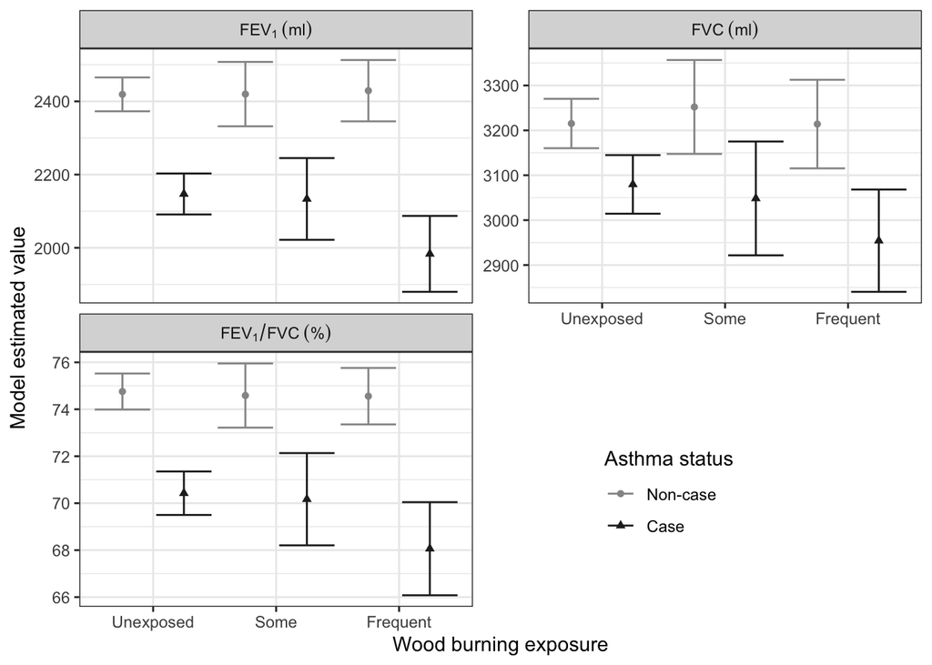

```r
pred_df_asthma %>%
  select(WoodExp, LHSScreen_12142015, FEV1, FVC, Ratio) %>%
  pivot_longer(cols = FEV1:Ratio, names_to = "PFT") %>%
  mutate(PFT = factor(PFT, levels = c("FEV1", "FVC", "Ratio"),
                      labels = c("FEV[1]~(ml)", "FVC~(ml)", "FEV[1]/FVC~('%')"))) %>%
  separate(value, into = c("Pred", "SE"), sep = "_") %>%
  mutate(Pred = as.numeric(Pred), SE = as.numeric(SE)) %>%
  mutate(LowCI = Pred - (1.96*SE), HighCI = Pred + (1.96*SE)) %>%
  select(-SE) %>%
  ggplot(aes(x = WoodExp, y = Pred, ymin = LowCI, ymax = HighCI,
             color = LHSScreen_12142015, shape = LHSScreen_12142015)) +
  geom_point(position = position_dodge(width = 1)) +
  geom_errorbar(position = position_dodge(width = 1)) +
  facet_wrap(~PFT, nrow = 2, scales = "free_y", labeller = label_parsed) +
  labs(x = "Wood burning exposure", y = "Model estimated value",
       color = "Asthma status", shape = "Asthma status") +
  scale_x_discrete(labels = c("Unexposed", "Some", "Frequent")) +
  scale_color_manual(values = RColorBrewer::brewer.pal(n = 6, name = "Greys")[c(4,6)],
                     labels = c("Non-case", "Case")) +
  scale_shape_manual(values = c(16, 17), labels = c("Non-case", "Case")) +
  theme_bw() + theme(legend.position = c(0.7, 0.2))
```

```r
#ggsave(filename = "../Manuscript/Fig1_Woodburning_Asthma_Interaction_Plot.jpg",
#       plot = last_plot(), device = "jpg", width = 6.5, height = 6.5, dpi = 300)
```

# Table S7: Unweighted associations by asthma status

```r
# Association stats
fev1_mod <- lm(formula = paste0("FEV1_01 ~ ", paste(covars, collapse = " + "),
                                "+ WoodExpAsthmaInt"),
               data = pheno_analysis)

fev1_results <-
  rbind(summary(fev1_mod)$coef %>%
          as.data.frame() %>%
          rownames_to_column("Covariate") %>%
          filter(grepl("Noncase", Covariate)) %>%
          mutate(Covariate = str_replace(Covariate, "WoodExpAsthmaInt", "")) %>%
          rename(SE = `Std. Error`, T = `t value`, P = `Pr(>|t|)`),
        as_tibble(svycontrast(fev1_mod, contrasts = contrast_list),
                  rownames = NA) %>%
          rownames_to_column("Covariate") %>%
          rename(Estimate = contrast) %>%
          mutate(T = Estimate/SE,
                 P = 2 * pt(abs(T), df = df.residual(fev1_mod),
                            lower.tail = FALSE))) %>%
  mutate(PFT = "FEV1")

fvc_mod <- lm(formula = paste0("FVC_01 ~ ", paste(fvc_covars, collapse = " + "),
                               "+ WoodExpAsthmaInt"),
              data = pheno_analysis)

fvc_results <-
  rbind(summary(fvc_mod)$coef %>%
          as.data.frame() %>%
          rownames_to_column("Covariate") %>%
          filter(grepl("Noncase", Covariate)) %>%
          mutate(Covariate = str_replace(Covariate, "WoodExpAsthmaInt", "")) %>%
          rename(SE = `Std. Error`, T = `t value`, P = `Pr(>|t|)`),
        as_tibble(svycontrast(fvc_mod, contrasts = contrast_list),
                  rownames = NA) %>%
          rownames_to_column("Covariate") %>%
          rename(Estimate = contrast) %>%
          mutate(T = Estimate/SE,
                 P = 2 * pt(abs(T), df = df.residual(fvc_mod),
                            lower.tail = FALSE))) %>%
  mutate(PFT = "FVC")

ratio_mod <- lm(formula = paste0("RATIO1_01_r ~ ", paste(covars, collapse = " + "),
                                 "+ WoodExpAsthmaInt"),
                data = pheno_analysis)

ratio_results <-
  rbind(summary(ratio_mod)$coef %>%
          as.data.frame() %>%
          rownames_to_column("Covariate") %>%
          filter(grepl("Noncase", Covariate)) %>%
          mutate(Covariate = str_replace(Covariate, "WoodExpAsthmaInt", "")) %>%
          rename(SE = `Std. Error`, T = `t value`, P = `Pr(>|t|)`),
        as_tibble(svycontrast(ratio_mod, contrasts = contrast_list),
                  rownames = NA) %>%
          rownames_to_column("Covariate") %>%
          rename(Estimate = contrast) %>%
          mutate(T = Estimate/SE,
                 P = 2 * pt(abs(T), df = df.residual(ratio_mod),
                            lower.tail = FALSE))) %>%
  mutate(PFT = "Ratio")

# Write table
multivar_results <- rbind(fev1_results, fvc_results, ratio_results)

multivar_results %>%
  separate(col = Covariate, into = c("WoodExp", "Asthma"), sep = "-") %>%
  mutate(LowCI = Estimate - (1.96 * SE),
         HighCI = Estimate + (1.96 * SE),
         Estimate = case_when(PFT %in% c("FEV1", "FVC") ~
                                   round(Estimate, digits = 0),
                                 PFT == "Ratio" ~ signif(Estimate, digits = 1)),
         LowCI = case_when(PFT %in% c("FEV1", "FVC") ~
                                round(LowCI, digits = 0),
                              PFT == "Ratio" ~ signif(LowCI, digits = 1)),
         HighCI = case_when(PFT %in% c("FEV1", "FVC") ~
                                 round(HighCI, digits = 0),
                               PFT == "Ratio" ~ signif(HighCI, digits = 1))) %>%
  dplyr::select(PFT, WoodExp, Asthma, Estimate, LowCI, HighCI) %>%
  mutate(LowCI = paste0("(", LowCI),
         HighCI = paste0(HighCI, ")")) %>%
  unite(col = CI, c(LowCI, HighCI), sep = ", ", remove = TRUE) %>%
  unite(col = Estimate, c(Estimate, CI), sep = "\n", remove = TRUE) %>%
  arrange(match(PFT, c("FEV1", "FVC", "Ratio"))) %>%
  pivot_wider(names_from = PFT, values_from = Estimate) %>%
  dplyr::select(WoodExp, Asthma, starts_with("FEV1"), starts_with("FVC"),
                starts_with("Ratio")) %>%
  flextable() %>%
  theme_box() %>%
  autofit() %>%
  align(align = "center", part = "all") #%>% print(preview = "docx")
```

| WoodExp | Asthma | FEV1 | FVC | Ratio |
| --- | --- | --- | --- | --- |
| Some | Noncase | 2 (-83, 86) | 35 (-60, 131) | -0.2 (-2, 1) |
| Freq | Noncase | 12 (-60, 85) | 2 (-80, 84) | -0.1 (-1, 1) |
| Some | Case | -15 (-115, 84) | -35 (-148, 79) | -0.2 (-2, 1) |
| Freq | Case | -165 (-254, -75) | -125 (-227, -24) | -2 (-4, -1) |

Sample sizes

```r
fev1_mod$model %>% group_by(WoodExpAsthmaInt) %>% summarize(N = n())
```

```
## # A tibble: 6 × 2
##   WoodExpAsthmaInt     N
##   <fct>            <int>
## 1 Unexp-Noncase     1378
## 2 Some-Noncase       145
## 3 Freq-Noncase       209
## 4 Unexp-Case         839
## 5 Some-Case          105
## 6 Freq-Case          139
```

Interaction product terms

```r
fev1_mod <- lm(formula = paste0("FEV1_01 ~ ", paste(covars, collapse = " + "),
                         " + WoodExp*LHSScreen_12142015"),
        data = pheno_analysis)

signif(summary(fev1_mod)$coef[last(rownames(summary(fev1_mod)$coef)),4], digits = 2)
```

```
## [1] 0.0023
```

```r
fvc_mod <- lm(formula = paste0("FVC_01 ~ ", paste(fvc_covars, collapse = " + "),
                             " + WoodExp*LHSScreen_12142015"),
            data = pheno_analysis)

signif(summary(fvc_mod)$coef[last(rownames(summary(fvc_mod)$coef)),4], digits = 2)
```

```
## [1] 0.053
```

```r
ratio_mod <- lm(formula = paste0("RATIO1_01_r ~ ", paste(covars, collapse = " + "),
                         " + WoodExp*LHSScreen_12142015"),
            data = pheno_analysis)

signif(summary(ratio_mod)$coef[last(rownames(summary(ratio_mod)$coef)),4], digits = 2)
```

```
## [1] 0.014
```

# Table S8: Values used when plotting Figure 1 and Figure S2

```r
rbind(pred_df_smoking %>% mutate(LHSScreen_12142015 = "", Model = "Smoking interaction") %>%
        select(Model, LHSScreen_12142015, LH_smoke_status, WoodExp, FEV1, FVC, Ratio),
      pred_df_asthma %>% mutate(Model = "Asthma interaction") %>%
        select(Model, LHSScreen_12142015, LH_smoke_status, WoodExp, FEV1, FVC, Ratio)) %>%
  pivot_longer(cols = FEV1:Ratio, names_to = "PFT") %>%
  separate(value, into = c("Pred", "SE"), sep = "_") %>%
  mutate(Pred = as.numeric(Pred),
         SE = as.numeric(SE),
         LowCI = Pred - (1.96 * SE),
         HighCI = Pred + (1.96 * SE),
         Pred = case_when(PFT %in% c("FEV1", "FVC") ~ round(Pred, digits = 0),
                          PFT == "Ratio" ~ round(Pred, digits = 1)),
         LowCI = case_when(PFT %in% c("FEV1", "FVC") ~ round(LowCI, digits = 0),
                           PFT == "Ratio" ~ round(LowCI, digits = 1)),
         HighCI = case_when(PFT %in% c("FEV1", "FVC") ~ round(HighCI, digits = 0),
                            PFT == "Ratio" ~ round(HighCI, digits = 1))) %>%
  dplyr::select(Model, LHSScreen_12142015, LH_smoke_status, WoodExp, PFT, Pred, LowCI, HighCI) %>%
  mutate(LowCI = paste0("(", LowCI),
         HighCI = paste0(HighCI, ")")) %>%
  unite(col = CI, c(LowCI, HighCI), sep = ", ", remove = TRUE) %>%
  unite(col = Pred, c(Pred, CI), sep = "\n", remove = TRUE) %>%
  arrange(match(PFT, c("FEV1", "FVC", "Ratio"))) %>%
  pivot_wider(names_from = PFT, values_from = Pred) %>%
  arrange(Model) %>%
  flextable() %>%
  theme_box() %>%
  autofit() %>%
  align(align = "center", part = "all") #%>% print(preview = "docx")
```

| Model | LHSScreen_12142015 | LH_smoke_status | WoodExp | FEV1 | FVC | Ratio |
| --- | --- | --- | --- | --- | --- | --- |
| Asthma interaction | 0 | 1 | 0 | 2419 (2373, 2465) | 3215 (3160, 3270) | 74.8 (74, 75.5) |
| Asthma interaction | 0 | 1 | 1 | 2420 (2332, 2508) | 3252 (3148, 3357) | 74.6 (73.2, 76) |
| Asthma interaction | 0 | 1 | 2 | 2429 (2345, 2513) | 3214 (3115, 3313) | 74.6 (73.4, 75.8) |
| Asthma interaction | 1 | 1 | 0 | 2147 (2091, 2203) | 3080 (3014, 3145) | 70.4 (69.5, 71.4) |
| Asthma interaction | 1 | 1 | 1 | 2133 (2022, 2245) | 3048 (2922, 3175) | 70.2 (68.2, 72.1) |
| Asthma interaction | 1 | 1 | 2 | 1983 (1880, 2087) | 2954 (2840, 3068) | 68.1 (66.1, 70) |
| Smoking interaction |  | 1 | 0 | 2401 (2355, 2448) | 3209 (3154, 3264) | 74.5 (73.7, 75.2) |
| Smoking interaction |  | 1 | 1 | 2386 (2296, 2476) | 3211 (3101, 3322) | 74.1 (72.7, 75.5) |
| Smoking interaction |  | 1 | 2 | 2416 (2326, 2506) | 3206 (3097, 3315) | 74.5 (73.4, 75.7) |
| Smoking interaction |  | 2 | 0 | 2408 (2349, 2467) | 3232 (3162, 3302) | 74.1 (73.1, 75) |
| Smoking interaction |  | 2 | 1 | 2433 (2281, 2585) | 3343 (3155, 3532) | 73.8 (71.5, 76.1) |
| Smoking interaction |  | 2 | 2 | 2399 (2282, 2516) | 3246 (3113, 3378) | 73.4 (71.5, 75.2) |
| Smoking interaction |  | 3 | 0 | 2303 (2151, 2456) | 3113 (2951, 3276) | 71.6 (69, 74.2) |
| Smoking interaction |  | 3 | 1 | 2314 (1844, 2784) | 3036 (2712, 3361) | 73.7 (66.3, 81.1) |
| Smoking interaction |  | 3 | 2 | 2185 (1914, 2456) | 2940 (2646, 3234) | 69.4 (64.4, 74.4) |

# Table 4: Sample weighted multivariable results for FeNO

Mean and SD overall and per group

```r
# Overall mean
signif(svymean(~FTSC_eNO_Average_Win_log,
        design = pheno_analysis_feno_surv), digits = 2)
```

```
##                          mean     SE
## FTSC_eNO_Average_Win_log  2.7 0.0146
```

```r
# Overall SD
jtools::svysd(~FTSC_eNO_Average_Win_log,
        design = pheno_analysis_feno_surv, digits = 2)
```

```
##                          std. dev.
## FTSC_eNO_Average_Win_log      0.63
```

```r
# Mean and SD by smoking status
gtsummary::tbl_svysummary(pheno_analysis_feno_surv, by = LH_smoke_status,
                          statistic = list(all_continuous() ~ "{mean} ({sd})"),
                          include = c("FTSC_eNO_Average_Win_log", "LH_smoke_status"))
```

| **Characteristic** | **1**, N = 1,677<sup>1</sup> | **2**, N = 784<sup>1</sup> | **3**, N = 137<sup>1</sup> |
| --- | --- | --- | --- |
| FTSC_eNO_Average_Win_log | 2.70 (0.62) | 2.76 (0.61) | 2.19 (0.63) |

<sup>*1*</sup> Mean (SD)

```r
# Mean by asthma status
svyby(~FTSC_eNO_Average_Win_log, ~LHSScreen_12142015,
      design = pheno_analysis_feno_surv, svymean) %>%
  mutate(FTSC_eNO_Average_Win_log = signif(FTSC_eNO_Average_Win_log, digits = 3))
```

```
##   LHSScreen_12142015 FTSC_eNO_Average_Win_log         se
## 0                  0                     2.68 0.01554122
## 1                  1                     2.87 0.02301133
```

```r
# SD for non-asthmatics
jtools::svysd(~FTSC_eNO_Average_Win_log,
              design = subset(pheno_analysis_feno_surv, LHSScreen_12142015 == 0),
              digits = 2)
```

```
##                          std. dev.
## FTSC_eNO_Average_Win_log      0.62
```

```r
# SD for asthmatics
jtools::svysd(~FTSC_eNO_Average_Win_log,
              design = subset(pheno_analysis_feno_surv, LHSScreen_12142015 == 1),
              digits = 2)
```

```
##                          std. dev.
## FTSC_eNO_Average_Win_log      0.73
```

Associations among all participants

```r
feno_covars <- c("pft_age", "gender", "race_B", "LH_Height", "LH_Weight", "state",
                 "LH_smoke_status", "LH_packyears", "Im_Atopic_Spec_v2")

feno_mod <- svyglm(formula =
                     paste0("FTSC_eNO_Average_Win_log ~ WoodExp + ",
                            paste(feno_covars, collapse = " + ")),
                   design = pheno_analysis_feno_surv)

feno_results <- summary(feno_mod)$coef %>%
  as.data.frame() %>%
  rownames_to_column("Covariate") %>%
  filter(grepl("WoodExp", Covariate)) %>%
  mutate(Covariate = str_replace_all(Covariate, c("WoodExp1" = "Some-All",
                                              "WoodExp2" = "Freq-All"))) %>%
  mutate(Group = "All") %>%
  rename(SE = `Std. Error`, T = `t value`, P = `Pr(>|t|)`)
```

Smoking interaction model

```r
contrast_list <- list("Some-Former" = c("WoodExpSmokingIntUnexp-Former"=-1,
                                        "WoodExpSmokingIntSome-Former"=1),
                      "Freq-Former" = c("WoodExpSmokingIntUnexp-Former"=-1,
                                        "WoodExpSmokingIntFreq-Former"=1),
                      "Some-Current" = c("WoodExpSmokingIntUnexp-Current"=-1,
                                         "WoodExpSmokingIntSome-Current"=1),
                      "Freq-Current" = c("WoodExpSmokingIntUnexp-Current"=-1,
                                         "WoodExpSmokingIntFreq-Current"=1))

feno_smoking_mod <- svyglm(formula = paste0("FTSC_eNO_Average_Win_log ~ ",
                                    paste(feno_covars[-which(feno_covars == "LH_smoke_status")],
                                          collapse = " + "), "+ WoodExpSmokingInt"),
                   design = pheno_analysis_feno_surv)

feno_smoking_results <-
  rbind(summary(feno_smoking_mod)$coef %>%
          as.data.frame() %>%
          rownames_to_column("Covariate") %>%
          filter(grepl("Never", Covariate)) %>%
          mutate(Covariate = str_replace(Covariate, "WoodExpSmokingInt", "")) %>%
          rename(SE = `Std. Error`, T = `t value`, P = `Pr(>|t|)`),
        as_tibble(svycontrast(feno_smoking_mod, contrasts = contrast_list),
                  rownames = NA) %>%
          rownames_to_column("Covariate") %>%
          rename(Estimate = contrast) %>%
          mutate(T = Estimate/SE,
                 P = 2 * pt(abs(T), df = df.residual(feno_smoking_mod),
                            lower.tail = FALSE))) %>%
  mutate(Group = "BySmoking")
```

Asthma interaction model

```r
contrast_list <- list("Some-Case" = c("WoodExpAsthmaIntUnexp-Case"=-1,
                                        "WoodExpAsthmaIntSome-Case"=1),
                      "Freq-Case" = c("WoodExpAsthmaIntUnexp-Case"=-1,
                                        "WoodExpAsthmaIntFreq-Case"=1))

feno_asthma_mod <- svyglm(formula = paste0("FTSC_eNO_Average_Win_log ~ ",
                                    paste(feno_covars, collapse = " + "),
                                    "+ WoodExpAsthmaInt"),
                   design = pheno_analysis_feno_surv)

feno_asthma_results <-
  rbind(summary(feno_asthma_mod)$coef %>%
          as.data.frame() %>%
          rownames_to_column("Covariate") %>%
          filter(grepl("Noncase", Covariate)) %>%
          mutate(Covariate = str_replace(Covariate, "WoodExpAsthmaInt", "")) %>%
          rename(SE = `Std. Error`, T = `t value`, P = `Pr(>|t|)`),
        as_tibble(svycontrast(feno_asthma_mod, contrasts = contrast_list),
                  rownames = NA) %>%
          rownames_to_column("Covariate") %>%
          rename(Estimate = contrast) %>%
          mutate(T = Estimate/SE,
                 P = 2 * pt(abs(T), df = df.residual(feno_asthma_mod),
                            lower.tail = FALSE))) %>%
  mutate(Group = "ByAsthma")
```

Write association results for table

```r
rbind(feno_results, feno_smoking_results, feno_asthma_results) %>%
  mutate(Estimate = signif(Estimate, digits = 1)) %>%
  mutate(LowCI = signif(Estimate - (1.96*SE), digits = 1),
         HighCI = signif(Estimate + (1.96*SE), digits = 1)) %>%
  mutate(LowCI = paste0("(", LowCI),
         HighCI = paste0(HighCI, ")")) %>%
  unite(col = CI, c(LowCI, HighCI), sep = ", ", remove = TRUE) %>%
  unite(col = "Estimate", c(Estimate, CI), sep = "\n", remove = TRUE) %>%
  select(-c(SE, `T`, P, Group)) %>%
  separate(col = Covariate, into = c("WoodExp", "Group"), sep = "-") %>%
  pivot_wider(names_from = WoodExp, values_from = Estimate) %>%
  flextable() %>%
  theme_box() %>%
  autofit() %>%
  align(align = "center", part = "all") #%>% print(preview = "docx")
```

| Group | Some | Freq |
| --- | --- | --- |
| All | 0.03 (-0.06, 0.1) | 0.1 (0.02, 0.2) |
| Never | -0.01 (-0.1, 0.1) | 0.1 (0.007, 0.2) |
| Former | 0.1 (-0.05, 0.2) | -0.02 (-0.2, 0.1) |
| Current | 0.09 (-0.4, 0.5) | 0.4 (0.1, 0.7) |
| Noncase | 0.02 (-0.08, 0.1) | 0.1 (0.02, 0.2) |
| Case | 0.04 (-0.09, 0.2) | 0.01 (-0.1, 0.1) |

Sample sizes

```r
# By wood burning exposure
feno_mod$model %>% group_by(WoodExp) %>% summarize(N = n())
```

```
## # A tibble: 3 × 2
##   WoodExp     N
##   <fct>   <int>
## 1 0        2040
## 2 1         235
## 3 2         323
```

```r
# By wood burning and smoking status
feno_smoking_mod$model %>% group_by(WoodExpSmokingInt) %>% summarize(N = n())
```

```
## # A tibble: 9 × 2
##   WoodExpSmokingInt     N
##   <fct>             <int>
## 1 Unexp-Never        1373
## 2 Some-Never          159
## 3 Freq-Never          189
## 4 Unexp-Former        583
## 5 Some-Former          68
## 6 Freq-Former         110
## 7 Unexp-Current        84
## 8 Some-Current          8
## 9 Freq-Current         24
```

```r
# By wood burning and asthma status
feno_asthma_mod$model %>% group_by(WoodExpAsthmaInt) %>% summarize(N = n())
```

```
## # A tibble: 6 × 2
##   WoodExpAsthmaInt     N
##   <fct>            <int>
## 1 Unexp-Noncase     1265
## 2 Some-Noncase       136
## 3 Freq-Noncase       193
## 4 Unexp-Case         775
## 5 Some-Case           99
## 6 Freq-Case          130
```

Interaction product terms

```r
# Smoking interaction
feno_smoking_mod <- svyglm(formula = paste0("FTSC_eNO_Average_Win_log ~ ",
                                            paste(feno_covars[-which(feno_covars == "LH_smoke_status")],
                                                  collapse = " + "),
                                            " + WoodExp*LH_smoke_status"),
                           design = pheno_analysis_feno_surv)

signif(summary(feno_smoking_mod)$coef[c("WoodExp2:LH_smoke_status2", "WoodExp2:LH_smoke_status3"),4],
       digits = 2)
```

```
## WoodExp2:LH_smoke_status2 WoodExp2:LH_smoke_status3
##                     0.097                     0.029
```

```r
# Asthma interaction
feno_asthma_mod <- svyglm(formula = paste0("FTSC_eNO_Average_Win_log ~  ",
                                           paste(feno_covars, collapse = " + "),
                                           " + WoodExp*LHSScreen_12142015"),
                          design = pheno_analysis_feno_surv)

signif(summary(feno_asthma_mod)$coef["WoodExp2:LHSScreen_121420151", 4], digits = 2)
```

```
## [1] 0.24
```

# Table S9: Unweighted associations with FeNO

Average and SD

```r
# All participants
tbl_summary(pheno_analysis_feno, include = FTSC_eNO_Average_Win_log,
            statistic = list(all_continuous() ~ "{mean} ({sd})"))
```

| **Characteristic** | **N = 2,598**<sup>1</sup> |
| --- | --- |
| FTSC_eNO_Average_Win_log | 2.75 (0.67) |

<sup>*1*</sup> Mean (SD)

```r
# By smoking status
tbl_summary(pheno_analysis_feno, by = LH_smoke_status,
            include = c(FTSC_eNO_Average_Win_log, LH_smoke_status),
            statistic = list(all_continuous() ~ "{mean} ({sd})"))
```

| **Characteristic** | **1**, N = 1,721<sup>1</sup> | **2**, N = 761<sup>1</sup> | **3**, N = 116<sup>1</sup> |
| --- | --- | --- | --- |
| FTSC_eNO_Average_Win_log | 2.77 (0.66) | 2.80 (0.64) | 2.14 (0.65) |

<sup>*1*</sup> Mean (SD)

```r
# By asthma status
tbl_summary(pheno_analysis_feno, by = LHSScreen_12142015,
            include = c(FTSC_eNO_Average_Win_log, LHSScreen_12142015),
            statistic = list(all_continuous() ~ "{mean} ({sd})"))
```

| **Characteristic** | **0**, N = 1,594<sup>1</sup> | **1**, N = 1,004<sup>1</sup> |
| --- | --- | --- |
| FTSC_eNO_Average_Win_log | 2.68 (0.62) | 2.87 (0.73) |

<sup>*1*</sup> Mean (SD)

```r
# All participants
feno_mod <- lm(formula =
                 paste0("FTSC_eNO_Average_Win_log ~ WoodExp + ",
                        paste(feno_covars, collapse = " + ")),
               data = pheno_analysis_feno)

feno_results <- summary(feno_mod)$coef %>%
  as.data.frame() %>%
  rownames_to_column("Covariate") %>%
  filter(grepl("WoodExp", Covariate)) %>%
  mutate(Covariate = str_replace_all(Covariate, c("WoodExp1" = "Some-All",
                                              "WoodExp2" = "Freq-All"))) %>%
  mutate(Group = "All") %>%
  rename(SE = `Std. Error`, T = `t value`, P = `Pr(>|t|)`)

# By smoking status
contrast_list <- list("Some-Former" = c("WoodExpSmokingIntUnexp-Former"=-1,
                                        "WoodExpSmokingIntSome-Former"=1),
                      "Freq-Former" = c("WoodExpSmokingIntUnexp-Former"=-1,
                                        "WoodExpSmokingIntFreq-Former"=1),
                      "Some-Current" = c("WoodExpSmokingIntUnexp-Current"=-1,
                                         "WoodExpSmokingIntSome-Current"=1),
                      "Freq-Current" = c("WoodExpSmokingIntUnexp-Current"=-1,
                                         "WoodExpSmokingIntFreq-Current"=1))

feno_smoking_mod <- lm(formula =
                         paste0("FTSC_eNO_Average_Win_log ~ ",
                                paste(
                                  feno_covars[-which(feno_covars == "LH_smoke_status")],
                                  collapse = " + "),
                                "+ WoodExpSmokingInt"),
                       data = pheno_analysis_feno)

feno_smoking_results <-
  rbind(summary(feno_smoking_mod)$coef %>%
          as.data.frame() %>%
          rownames_to_column("Covariate") %>%
          filter(grepl("Never", Covariate)) %>%
          mutate(Covariate = str_replace(Covariate, "WoodExpSmokingInt", "")) %>%
          rename(SE = `Std. Error`, T = `t value`, P = `Pr(>|t|)`),
        as_tibble(svycontrast(feno_smoking_mod, contrasts = contrast_list),
                  rownames = NA) %>%
          rownames_to_column("Covariate") %>%
          rename(Estimate = contrast) %>%
          mutate(T = Estimate/SE,
                 P = 2 * pt(abs(T), df = df.residual(feno_smoking_mod),
                            lower.tail = FALSE))) %>%
  mutate(Group = "BySmoking")

# By asthma status
contrast_list <- list("Some-Case" = c("WoodExpAsthmaIntUnexp-Case"=-1,
                                        "WoodExpAsthmaIntSome-Case"=1),
                      "Freq-Case" = c("WoodExpAsthmaIntUnexp-Case"=-1,
                                        "WoodExpAsthmaIntFreq-Case"=1))

feno_asthma_mod <- lm(formula = paste0("FTSC_eNO_Average_Win_log ~ ",
                                    paste(feno_covars, collapse = " + "),
                                    "+ WoodExpAsthmaInt"),
                   data = pheno_analysis_feno)

feno_asthma_results <-
  rbind(summary(feno_asthma_mod)$coef %>%
          as.data.frame() %>%
          rownames_to_column("Covariate") %>%
          filter(grepl("Noncase", Covariate)) %>%
          mutate(Covariate = str_replace(Covariate, "WoodExpAsthmaInt", "")) %>%
          rename(SE = `Std. Error`, T = `t value`, P = `Pr(>|t|)`),
        as_tibble(svycontrast(feno_asthma_mod, contrasts = contrast_list),
                  rownames = NA) %>%
          rownames_to_column("Covariate") %>%
          rename(Estimate = contrast) %>%
          mutate(T = Estimate/SE,
                 P = 2 * pt(abs(T), df = df.residual(feno_asthma_mod),
                            lower.tail = FALSE))) %>%
  mutate(Group = "ByAsthma")

# Write association statistics table
rbind(feno_results, feno_smoking_results, feno_asthma_results) %>%
  mutate(Estimate = signif(Estimate, digits = 1)) %>%
  mutate(LowCI = signif(Estimate - (1.96*SE), digits = 1),
         HighCI = signif(Estimate + (1.96*SE), digits = 1)) %>%
  mutate(LowCI = paste0("(", LowCI),
         HighCI = paste0(HighCI, ")")) %>%
  unite(col = CI, c(LowCI, HighCI), sep = ", ", remove = TRUE) %>%
  unite(col = "Estimate", c(Estimate, CI), sep = "\n", remove = TRUE) %>%
  select(-c(SE, `T`, Group, P)) %>%
  separate(col = Covariate, into = c("WoodExp", "Group"), sep = "-") %>%
  pivot_wider(names_from = WoodExp, values_from = Estimate) %>%
  flextable() %>%
  theme_box() %>%
  autofit() %>%
  align(align = "center", part = "all") #%>% print(preview = "docx")
```

| Group | Some | Freq |
| --- | --- | --- |
| All | 0.04 (-0.05, 0.1) | 0.09 (0.01, 0.2) |
| Never | 0.03 (-0.08, 0.1) | 0.1 (0.001, 0.2) |
| Former | 0.05 (-0.1, 0.2) | 0.04 (-0.09, 0.2) |
| Current | -0.02 (-0.5, 0.4) | 0.2 (-0.09, 0.5) |
| Noncase | 0.03 (-0.08, 0.1) | 0.1 (0.002, 0.2) |
| Case | 0.04 (-0.09, 0.2) | 0.03 (-0.09, 0.2) |

Sample sizes

```r
# Overall
feno_mod$model %>% group_by(WoodExp) %>% summarize(N = n())
```

```
## # A tibble: 3 × 2
##   WoodExp     N
##   <fct>   <int>
## 1 0        2040
## 2 1         235
## 3 2         323
```

```r
# By smoking
feno_smoking_mod$model %>% group_by(WoodExpSmokingInt) %>% summarize(N = n())
```

```
## # A tibble: 9 × 2
##   WoodExpSmokingInt     N
##   <fct>             <int>
## 1 Unexp-Never        1373
## 2 Some-Never          159
## 3 Freq-Never          189
## 4 Unexp-Former        583
## 5 Some-Former          68
## 6 Freq-Former         110
## 7 Unexp-Current        84
## 8 Some-Current          8
## 9 Freq-Current         24
```

```r
# By asthma
feno_asthma_mod$model %>% group_by(WoodExpAsthmaInt) %>% summarize(N = n())
```

```
## # A tibble: 6 × 2
##   WoodExpAsthmaInt     N
##   <fct>            <int>
## 1 Unexp-Noncase     1265
## 2 Some-Noncase       136
## 3 Freq-Noncase       193
## 4 Unexp-Case         775
## 5 Some-Case           99
## 6 Freq-Case          130
```

Interaction product terms

```r
# Smoking
feno_smoking_mod <- lm(formula =
                         paste0("FTSC_eNO_Average_Win_log ~ ",
                                paste(feno_covars[-which(feno_covars == "LH_smoke_status")],
                                      collapse = " + "),
                                " + WoodExp*LH_smoke_status"),
                       data = pheno_analysis_feno)

signif(summary(feno_smoking_mod)$coef[c("WoodExp2:LH_smoke_status2",
                                        "WoodExp2:LH_smoke_status3"),4],
       digits = 2)
```

```
## WoodExp2:LH_smoke_status2 WoodExp2:LH_smoke_status3
##                      0.40                      0.68
```

```r
# Asthma
feno_asthma_mod <- lm(formula = paste0("FTSC_eNO_Average_Win_log ~ ",
                                       paste(feno_covars, collapse = " + "),
                                       " + WoodExp*LHSScreen_12142015"),
                      data = pheno_analysis_feno)

signif(summary(feno_asthma_mod)$coef["WoodExp2:LHSScreen_121420151", 4], digits = 2)
```

```
## [1] 0.25
```